# Scoliosis Model

Autor

Caio Vallio

Data de Publicação

7 de abril de 2026

Resumo

**Contexto:** A escoliose idiopática do adolescente pode apresentar resposta clínica variável a intervenções conservadoras. **Objetivo:** Explorar associações entre características basais e evolução radiográfica em 6 meses, utilizando abordagem estatística otimizada. **Métodos:** Estudo observacional com análise exploratória e inferencial. Implementamos três tipos de modelos: (1) modelo linear único para o desfecho contínuo $\Delta$ (mudança na maior curva), (2) modelos logísticos para desfechos binários de melhora clínica ($\Delta \le -5°$) e progressão clínica ($\Delta \ge +5°$), e (3) modelos CART para identificação de perfis de risco. Realizamos diagnósticos completos de adequação para todos os modelos, reportando coeficientes/odds ratios com IC95%.

## 0.1 Como reproduzir

- O arquivo de dados é lido de `data/dataset_escoliose_01.xlsx` (aba `dados`).
- As análises dependem de pacotes R listados no chunk de setup; caso algum pacote esteja ausente, o documento interrompe a execução com uma mensagem explícita.

## 0.2 Objetivo e delineamento

Este é um relatório **exploratório e inferencial**: o objetivo é **estimar associações ajustadas** entre variáveis basais e a evolução radiográfica em 6 meses.

## 0.3 Estrutura dos Modelos

A análise utiliza uma abordagem estatística otimizada com três tipos de modelos complementares:

### 0.3.1 Modelo Linear (Desfecho Contínuo)

- **Objetivo:** Modelar diretamente o $\Delta$ (mudança na maior curva em graus)
- **Interpretação:** Coeficientes negativos indicam associação com melhora, positivos com piora
- **Vantagem:** Aproveita toda a informação contínua do desfecho, sem perda por dicotomização

### 0.3.2 Modelos para Desfechos Binários

- **Melhora Clínica** ($\Delta \le -5°$): Modelos logístico e CART
- **Progressão Clínica** ($\Delta \ge +5°$): Modelos logístico e CART
- **Objetivo:** Identificar fatores associados aos desfechos clinicamente relevantes e perfis de risco

## 0.4 Definições de desfecho

- **Desfecho contínuo:** $\Delta$ = (maior curva em 6 meses − maior curva baseline), em graus. Valores negativos indicam melhora, positivos indicam piora.
- **Melhora clínica:** $\Delta \le -5°$ (redução de pelo menos 5 graus na maior curva).
- **Progressão clínica:** $\Delta \ge +5°$ (aumento de pelo menos 5 graus na maior curva).

## 0.5 Plano de análise estatística

- **Descrição da amostra**: estatísticas descritivas das variáveis preditoras e desfechos.
- **Inferência (associações ajustadas)**:
  - **Modelo linear único** para $\Delta$ (coeficientes com IC95%, interpretação direcionada).
  - **Modelos logísticos específicos** para melhora e progressão (odds ratios com IC95%).
  - **Modelos CART** para ambos os desfechos binários (regras interpretáveis e perfis de risco).
- **Adequação dos modelos**: diagnósticos completos de pressupostos para todos os modelos (normalidade, heteroscedasticidade, colinearidade, outliers, adequação do ajuste).
- **Forma funcional**: relações aproximadamente lineares entre preditores contínuos e desfechos.

Por se tratar de análise **exploratória**, os resultados devem ser interpretados com cautela, com ênfase em **magnitude/direção** e incerteza (IC95%).

**Código**

```r
# =============================================================================
# SETUP E PREPARAÇÃO DOS DADOS
# =============================================================================

## Carregamento e verificação de pacotes necessários
pkgs <- c(
    "tidyverse", # manipulação de dados e visualização
    "gtsummary", # tabelas estatísticas
    "readxl", # leitura de arquivos Excel
    "janitor", # limpeza de nomes de variáveis
    "performance", # diagnósticos de modelos
    "qqplotr", # gráficos Q-Q
    "PupillometryR" # gráficos violin plot
)

# Verificar se todos os pacotes estão instalados
missing_pkgs <- pkgs[!vapply(pkgs, requireNamespace, logical(1), quietly = TRUE)]
if (length(missing_pkgs) > 0) {
    stop("Pacotes ausentes: ", paste(missing_pkgs, collapse = ", "))
}

# Carregar pacotes
invisible(lapply(pkgs, library, character.only = TRUE))

# Configura<U+00E7><U+00F5>es de reprodutibilidade e tema
set.seed(123)
theme_set(theme_minimal())


## Leitura dos dados
df_raw <- readxl::read_excel(
    "data/dataset_escoliose_01.xlsx",
    sheet = "dados",
    na = "" # tratar células vazias como NA
)

## Limpeza dos nomes das variáveis (snake_case)
df <- df_raw |> janitor::clean_names()

# =============================================================================
# CRIAÇÃO DE VARIÁVEIS DERIVADAS
# =============================================================================

## Classificação do escoliômetro: identificar regi<U+00F5>es com deformidade > 10°
# Esta variável indica onde a gibosidade é mais pronunciada
df <- df |>
    mutate(
        escoliometro_maior_10_graus = case_when(
            # Múltiplas regi<U+00F5>es afetadas
            (escoliometro_cervical > 10) & (escoliometro_torarica > 10) & (escoliometro_lombar > 10) ~
                "cervical_toracica_lombar",
            (escoliometro_cervical > 10) & (escoliometro_torarica > 10) ~
                "cervical_toracica",
            (escoliometro_cervical > 10) & (escoliometro_lombar > 10) ~
                "cervical_lombar",
            (escoliometro_torarica > 10) & (escoliometro_lombar > 10) ~
                "toracica_lombar",

            # Região única afetada
            (escoliometro_cervical > 10) ~ "cervical",
            (escoliometro_torarica > 10) ~ "toracica",
            (escoliometro_lombar > 10) ~ "lombar",

            # Nenhuma região > 10° (referência)
            TRUE ~ "normal"
        )
    )

# Variáveis categóricas não são mais utilizadas nos modelos finais
# (mantendo apenas as variáveis numéricas conforme plano de análise)

## Cálculo do Índice de Massa Corporal (IMC)
df <- df |>
    mutate(imc = peso / (altura)^2) # altura deve estar em metros

# =============================================================================
# DEFINIÇÃO DOS DESFECHOS PRIMÁRIOS
# =============================================================================

## Identificação da maior curva no baseline
# Compara as três regi<U+00F5>es e identifica o maior ângulo de Cobb inicial
df <- df |>
    mutate(
        # Maior curva entre todas as regi<U+00F5>es medidas
        cobb_inicial_maior = pmax(
            cobb_toracico_proximal,
            cobb_toracica,
            cobb_lombar,
            na.rm = TRUE
        ),

        # Identificar qual região apresenta a maior curva (para referência)
        regiao_cobb_inicial = case_when(
            cobb_inicial_maior == cobb_toracico_proximal ~ "toracico_proximal",
            cobb_inicial_maior == cobb_toracica ~ "toracica",
            cobb_inicial_maior == cobb_lombar ~ "lombar",
            TRUE ~ NA_character_
        )
    )


# =============================================================================
# CRIAÇÃO DAS VARIÁVEIS DE DESFECHO
# =============================================================================

## Variáveis de desfecho para os dois modelos principais
df <- df |>
    # DESFECHO CONTÍNUO: Mudan<U+00E7>a na maior curva (em graus)
    # Valores negativos = melhora, valores positivos = piora
    mutate(delta = maior_curva_6_meses - cobb_inicial_maior) |>
    # MODELO 1: MELHORA CLÍNICA (delta ≤ -5°)
    mutate(
        delta_cat = if_else(delta <= -5, 1, 0),
        delta_cat_f = factor(
            delta_cat,
            levels = c(0, 1),
            labels = c("Sem melhora (MCID)", "Melhora (MCID)")
        )
    ) |>
    # MODELO 2: PROGRESS<U+00C3>O CLÍNICA (delta ≥ +5°)
    mutate(
        delta_progression = if_else(delta >= 5, 1, 0),
        delta_progression_f = factor(
            delta_progression,
            levels = c(0, 1),
            labels = c("Não progrediu", "Progrediu")
        )
    )

# Conversão de variáveis para tipos adequados nos modelos
df <- df |>
    mutate(
        # Variáveis numéricas
        idade = as.double(idade),

        # Variáveis categóricas (fatores com níveis específicos)
        lenke = as.factor(lenke),
        risser = as.factor(risser),
        sexo = as.factor(sexo),
        flexibilidade = as.factor(flexibilidade),

        # Escoliômetro: definir "normal" como categoria de referência
        escoliometro_maior_10_graus = forcats::fct_relevel(
            as.factor(escoliometro_maior_10_graus),
            "normal"
        )
    )
```

## 0.6 Dados faltantes e tamanho amostral

**Código**

```r
# =============================================================================
# ANÁLISE DE DADOS FALTANTES
# =============================================================================

# Calcular quantidade e percentual de dados faltantes por variável
missing_tbl <- df |>
    summarise(across(everything(), ~ sum(is.na(.)))) |>
    pivot_longer(
        everything(),
        names_to = "variavel",
        values_to = "n_missing"
    ) |>
    mutate(pct_missing = n_missing / nrow(df)) |>
    arrange(desc(pct_missing)) # ordenar por maior percentual faltante

# Exibir tabela de dados faltantes (formato percentual)
missing_tbl |>
    mutate(pct_missing = scales::percent(pct_missing, accuracy = 0.1)) |>
    print(n = 50)
```

```
# A tibble: 28 × 3
   variavel                    n_missing pct_missing
   <chr>                           <int> <chr>
 1 cobb_toracico_proximal            506 81.5%
 2 escoliometro_cervical             266 42.8%
 3 cobb_lombar                        38 6.1%
 4 escoliometro_lombar                32 5.2%
 5 cobb_toracica                      23 3.7%
 6 escoliometro_torarica              17 2.7%
 7 lenke                               3 0.5%
 8 id                                  0 0.0%
 9 idade                               0 0.0%
10 sexo                                0 0.0%
11 altura                              0 0.0%
12 peso                                0 0.0%
```

[output cut: 16 more lines]

**Código**

```r
# Tratamento de dados faltantes
# Remover observa<U+00E7><U+00F5>es com flexibilidade faltante (variável key do modelo)
df <- df |> drop_na(flexibilidade)
```

**Observação:** os modelos abaixo usam **análise por caso completo** (listwise deletion), que é o comportamento padrão do `glm()`/`lm()` quando há dados faltantes nas variáveis do modelo.

## 0.7 Codificação de variáveis categóricas (referências)

As variáveis categóricas entram como fatores. A **categoria de referência** (baseline) é o **primeiro nível** do fator (conforme `levels()`), a menos que seja explicitamente reordenado.

**Código**

```r
# Lista de variáveis categóricas utilizadas nos modelos finais
categoricas <- c(
    "sexo",
    "lenke",
    "risser",
    "flexibilidade",
    "escoliometro_maior_10_graus"
)
map_dfr(categoricas, function(v) {
    tibble(
        variavel = v,
        niveis = paste(levels(df[[v]]), collapse = " | ")
    )
}) |>
    print(n = Inf)
```

```
# A tibble: 5 × 2
  variavel                    niveis
  <chr>                       <chr>
1 sexo                        feminino | masculino
2 lenke                       1 | 2 | 3 | 4 | 5 | 6
3 risser                      0 | 1 | 2 | 3 | 4
4 flexibilidade               flexivel | rigido
5 escoliometro_maior_10_graus normal | lombar | toracica | toracica_lombar
```

# 1 Análise descritiva

## 1.1 Variáveis preditoras dos modelos

Variáveis coletadas na linha de base e utilizadas nos modelos finais.

**Código**

```r
df |>
    gtsummary::tbl_summary(
        include = c(
            # Variáveis numéricas
            idade,
            imc,
            cifose_toracica,
            lordose_lombar,
            correcao_colete,

            # Variáveis categóricas
            sexo,
            lenke,
            risser,
            flexibilidade,
            escoliometro_maior_10_graus,
        ),
        type = list(
            idade ~ "continuous"
        ),
        statistic = list(
            gtsummary::all_continuous() ~ "{mean} ({sd})",
            gtsummary::all_categorical() ~ "{n} ({p}%)"
        )
    )
```

| **Characteristic** | **N = 621**<sup>1</sup> |
| --- | --- |
| idade | 13.19 (1.70) |
| imc | 19.21 (2.92) |
| cifose_toracica | 23 (11) |
| lordose_lombar | 55 (12) |
| correcao_colete | 47 (20) |
| sexo |  |
| feminino | 556 (90%) |
| masculino | 65 (10%) |
| lenke |  |
| 1 | 37 (6.0%) |
| 2 | 41 (6.6%) |
| 3 | 137 (22%) |
| 4 | 60 (9.7%) |
| 5 | 55 (8.9%) |
| 6 | 288 (47%) |
| Unknown | 3 |
| risser |  |
| 0 | 132 (21%) |
| 1 | 95 (15%) |
| 2 | 124 (20%) |
| 3 | 127 (20%) |
| 4 | 143 (23%) |
| flexibilidade |  |
| flexivel | 393 (63%) |
| rigido | 228 (37%) |
| escoliometro_maior_10_graus |  |
| normal | 147 (24%) |
| lombar | 204 (33%) |
| toracica | 224 (36%) |
| toracica_lombar | 46 (7.4%) |

<sup>1</sup> Mean (SD); n (%)

## 1.2 Desfechos principais

- Maior curva na linha de base e em 6 meses.
- Delta: maior curva 6 meses - maior curva baseline.
- **Melhora clínica:** delta ≤ -5 graus (redução de pelo menos 5 graus).
- **Progressão clínica:** delta ≥ +5 graus (aumento de pelo menos 5 graus).

**Código**

```r
df |>
    gtsummary::tbl_summary(
        include = c(
            cobb_inicial_maior,
            maior_curva_6_meses,
            delta,
            delta_cat_f,
            delta_progression_f
        ),
        type = list(
            delta_cat_f ~ "categorical",
            delta_progression_f ~ "categorical"
        ),
        statistic = list(
            gtsummary::all_continuous() ~ "{mean} ({sd})",
            gtsummary::all_categorical() ~ "{n} ({p}%)"
        )
    )
```

| **Characteristic** | **N = 621**<sup>1</sup> |
| --- | --- |
| cobb_inicial_maior | 36.6 (5.6) |
| maior_curva_6_meses | 32 (8) |
| delta | -4.6 (5.4) |
| delta_cat_f |  |
| Sem melhora (MCID) | 301 (48%) |
| Melhora (MCID) | 320 (52%) |
| delta_progression_f |  |
| Não progrediu | 596 (96%) |
| Progrediu | 25 (4.0%) |

<sup>1</sup> Mean (SD); n (%)

## 1.3 Distribuição do desfecho principal

**Código**

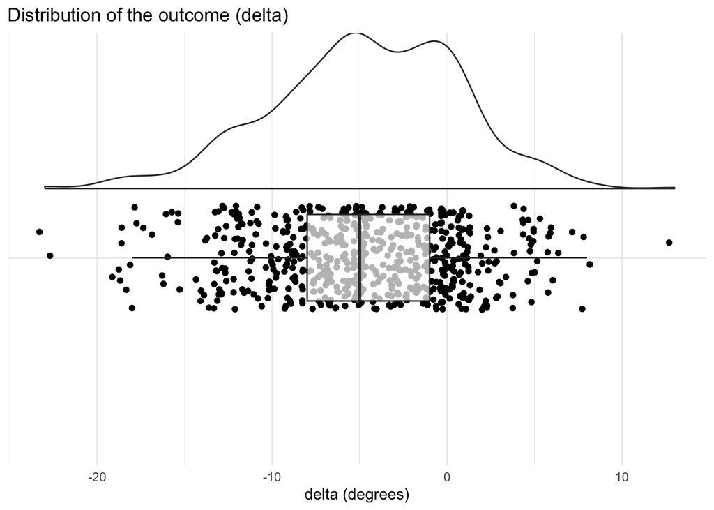

```r
df |>
    ggplot(aes(x = "", y = delta)) +
    PupillometryR::geom_flat_violin(
        position = position_nudge(x = .2),
        alpha = 0.7
    ) +
    labs(
        title = "Distribution of the outcome (delta)",
        x = "",
        y = "delta (degrees)"
    ) +
    geom_point(position = position_jitter(w = .15)) +
    geom_boxplot(
        width = .25,
        alpha = 0.7,
        outlier.shape = NA
    ) +
    coord_flip() +
    theme(
        axis.title.y = element_blank(),
        axis.text.y = element_blank(),
        axis.ticks.y = element_blank()
    )
```

**Código**

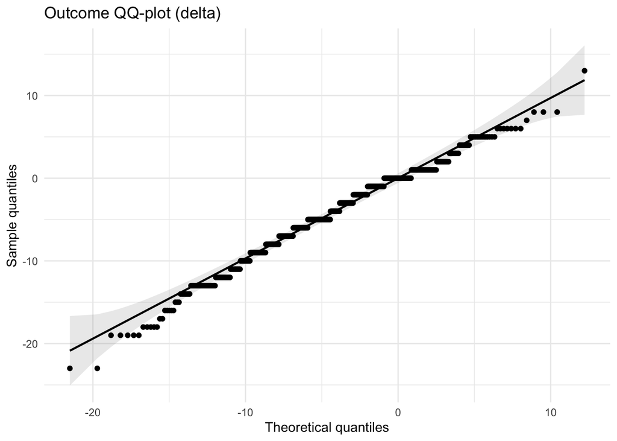

```r
df |>
    ggplot(aes(sample = delta)) +
    qqplotr::stat_qq_band(alpha = 0.2) +
    qqplotr::stat_qq_line() +
    qqplotr::stat_qq_point() +
    labs(
        title = "Outcome QQ-plot (delta)",
        x = "Theoretical quantiles",
        y = "Sample quantiles"
    )
```

# 2 Modelagem

## 2.1 Modelo Linear - Desfecho Contínuo (Delta)

### 2.1.1 Interpretação dos coeficientes

Os coeficientes do modelo linear representam a mudança esperada no $\Delta$ (em graus) para cada unidade de aumento na variável preditora:

- **Coeficientes negativos:** indicam associação com **melhora clínica** (redução na curvatura)
- **Coeficientes positivos:** indicam associação com **progressão clínica** (aumento na curvatura)
- **Magnitude:** quantifica o efeito em graus de mudança na maior curva
- **Intervalos de confiança:** estimam a precisão e significância estatística dos efeitos

**Código**

```r
# =============================================================================
# MODELO LINEAR - DESFECHO CONTÍNUO (DELTA)
# =============================================================================

# Modelo único para o desfecho contínuo (delta em graus)
# Interpretação direta: coeficientes negativos = melhora, positivos = piora
# Utiliza toda a informação contínua sem perda por dicotomização

model_delta <- lm(
    delta ~
        # Variáveis numéricas
        idade + # idade do paciente
        imc + # índice de massa corporal
        cifose_toracica + # ângulo da cifose torácica
        lordose_lombar + # ângulo da lordose lombar
        correcao_colete + # percentual de correção com colete

        # Variáveis categóricas
        sexo + # sexo do paciente
        lenke + # classificação de Lenke (numérica como factor)
        risser + # sinal de Risser (numérica como factor)
        flexibilidade + # flexibilidade da curva
        escoliometro_maior_10_graus, # região com gibosidade > 10°
    data = df
)
```

### 2.1.2 Parâmetros do modelo

**Código**

```r
model_delta |>
    gtsummary::tbl_regression(conf.level = 0.95) |>
    # gtsummary::add_global_p() |>
    gtsummary::bold_p() |>
    gtsummary::bold_labels() |>
    gtsummary::italicize_levels()
```

| **Characteristic** | **Beta** | **95% CI** | **p-value** |
| --- | --- | --- | --- |
| idade | 0.06 | -0.21, 0.32 | 0.7 |
| imc | 0.02 | -0.10, 0.13 | 0.8 |
| cifose_toracica | -0.04 | -0.07, 0.00 | 0.039 |
| lordose_lombar | -0.01 | -0.04, 0.02 | 0.6 |
| correcao_colete | -0.12 | -0.14, -0.11 | <0.001 |
| sexo |  |  |  |
| feminino | — | — |  |
| masculino | -0.63 | -1.8, 0.55 | 0.3 |
| lenke |  |  |  |
| 1 | — | — |  |
| 2 | 0.22 | -1.7, 2.1 | 0.8 |
| 3 | 3.7 | 2.2, 5.3 | <0.001 |
| 4 | 4.2 | 2.4, 5.9 | <0.001 |
| 5 | 1.1 | -0.74, 3.0 | 0.2 |
| 6 | 2.3 | 0.76, 3.9 | 0.004 |
| risser |  |  |  |
| 0 | — | — |  |
| 1 | -2.6 | -3.7, -1.4 | <0.001 |
| 2 | -1.9 | -3.1, -0.83 | <0.001 |
| 3 | -1.3 | -2.4, -0.16 | 0.025 |
| 4 | -0.89 | -2.2, 0.40 | 0.2 |
| flexibilidade |  |  |  |
| flexivel | — | — |  |
| rigido | 0.91 | 0.18, 1.6 | 0.015 |
| escoliometro_maior_10_graus |  |  |  |
| normal | — | — |  |
| lombar | -0.40 | -1.4, 0.56 | 0.4 |
| toracica | -0.03 | -1.1, 0.98 | >0.9 |
| toracica_lombar | 2.7 | 1.3, 4.1 | <0.001 |

Abbreviation: CI = Confidence Interval

### 2.1.3 Análises de pressupostos

#### 2.1.3.1 Heteroscedasticidade

Verificação de heteroscedasticidade dos resíduos (teste de Breusch-Pagan).

**Código**

```r
performance::check_heteroscedasticity(model_delta)
```

```
OK: Error variance appears to be homoscedastic (p = 0.095).
```

**Código**

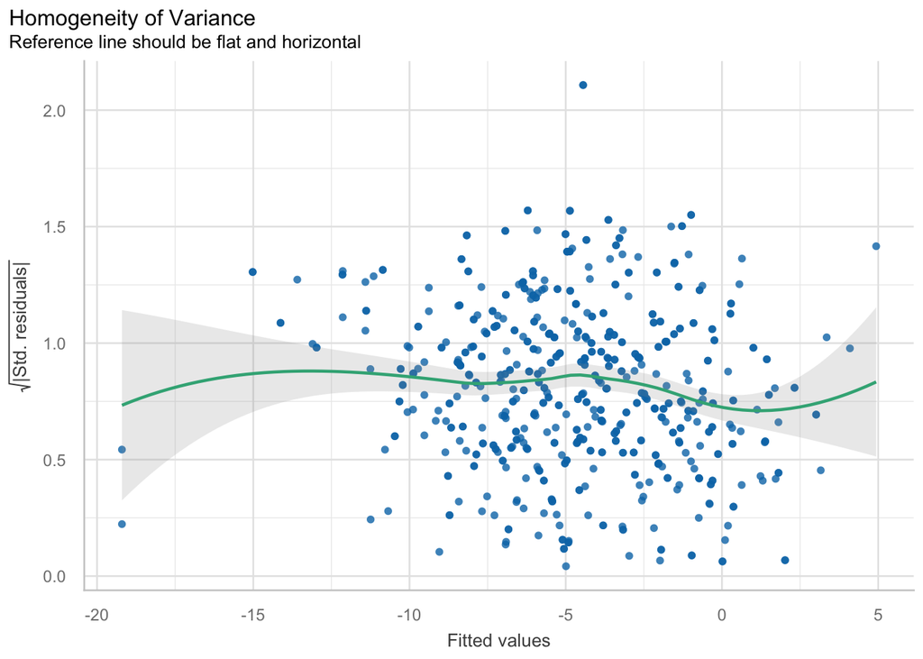

```r
performance::check_heteroscedasticity(model_delta) |> plot()
```

#### 2.1.3.2 Normalidade dos resíduos

**Código**

```r
performance::check_residuals(model_delta)
```

```
OK: Simulated residuals appear as uniformly distributed (p = 0.487).
```

**Código**

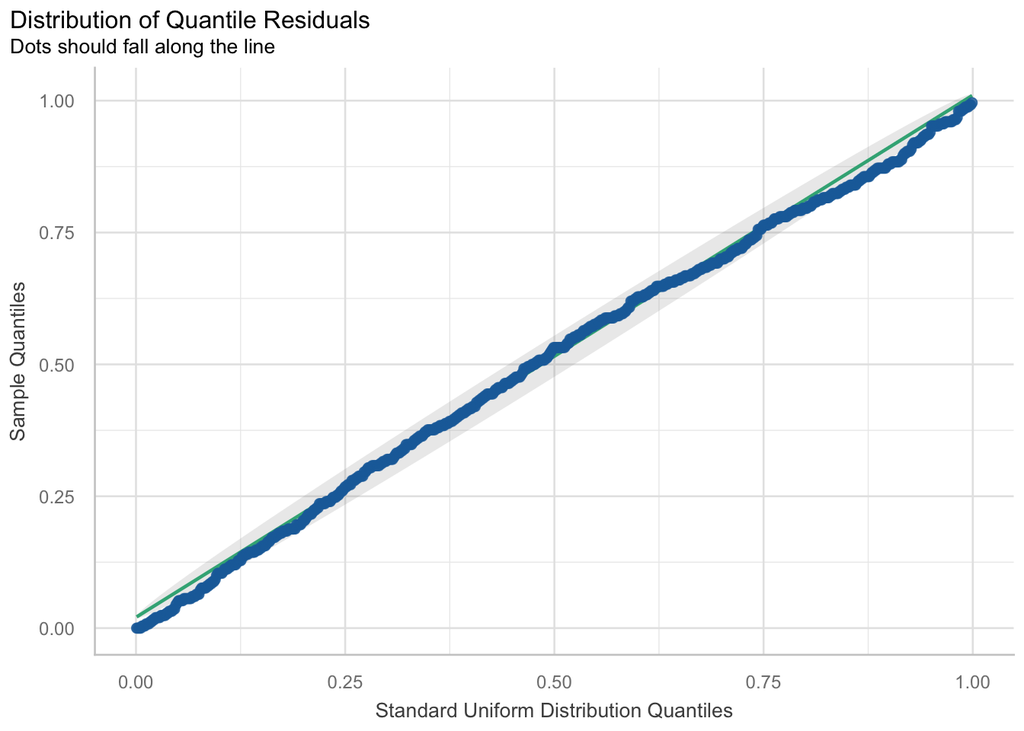

```r
performance::check_residuals(model_delta) |> plot()
```

#### 2.1.3.3 Autocorrelação dos resíduos

Independência dos resíduos (Durbin-Watson test).

**Código**

```r
performance::check_autocorrelation(model_delta)
```

```
OK: Residuals appear to be independent and not autocorrelated (p = 0.090).
```

#### 2.1.3.4 Verificações preditivas posteriores

Simulação de dados replicados sob o modelo ajustado e posterior comparação com os dados observados.

**Código**

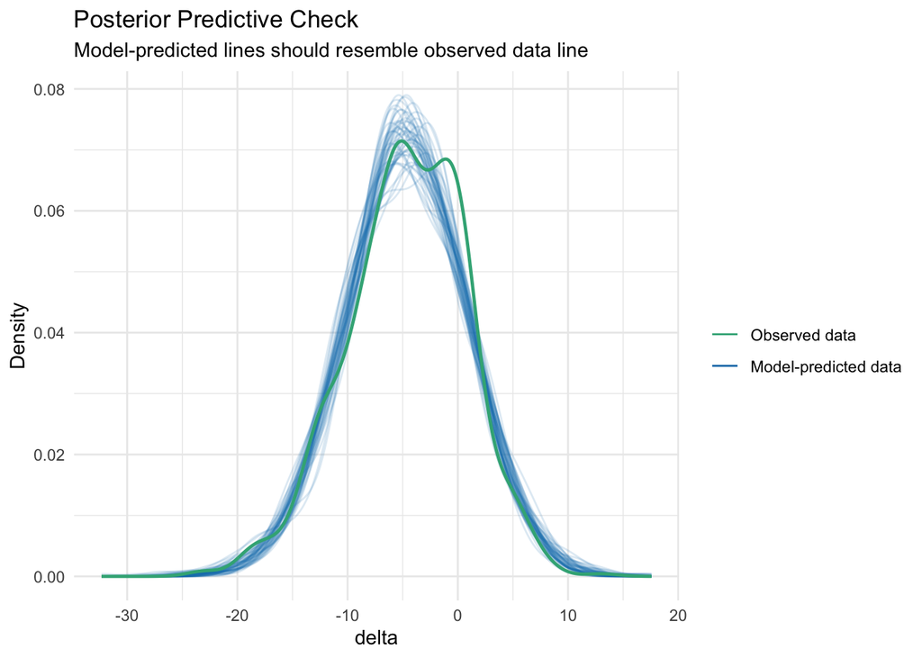

```r
performance::check_predictions(model_delta) |> plot()
```

#### 2.1.3.5 Colinearidade

Verificação de colinearidade entre as variáveis independentes (*Variance Inflation Factor*). Valores maiores que 10 indicam colinearidade entre as variáveis.

**Código**

```r
performance::check_collinearity(model_delta) |>
    arrange(desc(VIF)) |>
    select(Term, VIF, VIF_CI_low, VIF_CI_high) |>
    performance::print_html()
```

| Term | VIF | VIF_CI_low | VIF_CI_high |
| --- | --- | --- | --- |
| lenke | 2.26 | 2.02 | 2.56 |
| escoliometro_maior_10_graus | 2.17 | 1.94 | 2.46 |
| risser | 1.97 | 1.77 | 2.22 |
| idade | 1.80 | 1.63 | 2.03 |
| cifose_toracica | 1.45 | 1.33 | 1.62 |
| lordose_lombar | 1.37 | 1.26 | 1.52 |
| sexo | 1.17 | 1.09 | 1.31 |
| correcao_colete | 1.11 | 1.05 | 1.26 |
| flexibilidade | 1.11 | 1.05 | 1.25 |
| imc | 1.10 | 1.04 | 1.25 |

**Código**

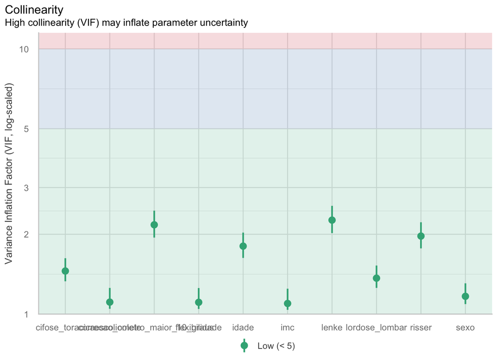

```r
performance::check_collinearity(model_delta) |> plot()
```

#### 2.1.3.6 Outliers

**Código**

```r
performance::check_outliers(model_delta)
```

```
OK: No outliers detected.
- Based on the following method and threshold: cook (0.9).
- For variable: (Whole model)
```

**Código**

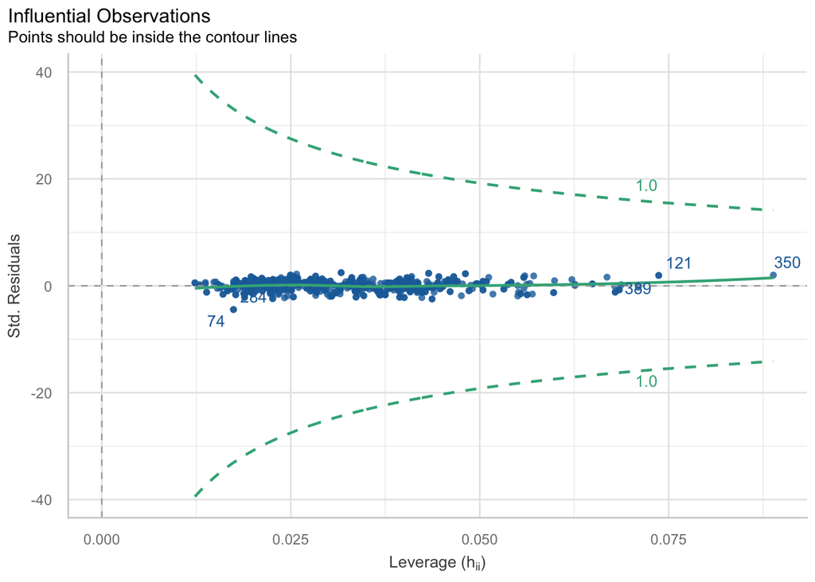

```r
performance::check_outliers(model_delta) |> plot()
```

#### 2.1.3.7 Coeficiente de determinação

$R^2$ - proporção da variância explicada pelo modelo.

**Código**

```r
performance::r2(model_delta)
```

```
# R2 for Linear Regression
       R2: 0.400
  adj. R2: 0.381
```

#### 2.1.3.8 Tamanho amostral efetivo (casos completos)

**Código**

```r
tibble(n_modelo = nobs(model_delta))
```

| n_modelo |
| --- |
| 618 |

## 2.2 Desfecho Binário: Melhora Clínica

Análise da **melhora clínica**, definida como redução ≥ 5 graus na maior curva ($\Delta \le -5°$).

### 2.2.1 Modelo Logístico

Estima associações ajustadas com a **chance de melhora clínica**, definida como $\Delta \le -5°$.

**Código**

```r
# =============================================================================
# MODELO LOGÍSTICO - MELHORA CLÍNICA
# =============================================================================

# Modelo para chance de melhora clínica (delta ≤ -5°)
# Utiliza as mesmas variáveis do modelo linear

model_melhora <- glm(
    delta_cat ~
        # Variáveis numéricas
        idade + # idade do paciente
        imc + # índice de massa corporal
        cifose_toracica + # ângulo da cifose torácica
        lordose_lombar + # ângulo da lordose lombar
        correcao_colete + # percentual de correção com colete

        # Variáveis categóricas
        sexo + # sexo do paciente
        lenke + # classificação de Lenke
        risser + # sinal de Risser
        flexibilidade + # flexibilidade da curva
        escoliometro_maior_10_graus, # região com gibosidade > 10°
    data = df,
    family = "binomial" # distribuição binomial para regressão logística
)
```

#### 2.2.1.1 Parâmetros do modelo

Parâmetros do modelo de regressão logística. Resposta em *Odds Ratio*.

**Código**

```r
model_melhora |>
    gtsummary::tbl_regression(exponentiate = TRUE, conf.level = 0.95) |>
    # gtsummary::add_global_p() |>
    gtsummary::bold_p() |>
    gtsummary::bold_labels() |>
    gtsummary::italicize_levels()
```

| **Characteristic** | **OR** | **95% CI** | **p-value** |
| --- | --- | --- | --- |
| idade | 0.93 | 0.78, 1.10 | 0.4 |
| imc | 1.05 | 0.98, 1.13 | 0.15 |
| cifose_toracica | 1.02 | 1.00, 1.04 | 0.049 |
| lordose_lombar | 0.99 | 0.97, 1.01 | 0.3 |
| correcao_colete | 1.10 | 1.08, 1.12 | <0.001 |
| sexo |  |  |  |
| feminino | — | — |  |
| masculino | 3.05 | 1.44, 6.64 | 0.004 |
| lenke |  |  |  |
| 1 | — | — |  |
| 2 | 0.41 | 0.12, 1.38 | 0.2 |
| 3 | 0.17 | 0.06, 0.44 | <0.001 |
| 4 | 0.13 | 0.04, 0.40 | <0.001 |
| 5 | 0.37 | 0.11, 1.18 | 0.10 |
| 6 | 0.20 | 0.07, 0.53 | 0.002 |
| risser |  |  |  |
| 0 | — | — |  |
| 1 | 6.16 | 2.90, 13.5 | <0.001 |
| 2 | 2.34 | 1.16, 4.77 | 0.019 |
| 3 | 1.19 | 0.59, 2.41 | 0.6 |
| 4 | 1.96 | 0.88, 4.42 | 0.10 |
| flexibilidade |  |  |  |
| flexivel | — | — |  |
| rigido | 0.61 | 0.39, 0.96 | 0.034 |
| escoliometro_maior_10_graus |  |  |  |
| normal | — | — |  |
| lombar | 1.03 | 0.58, 1.82 | >0.9 |
| toracica | 0.96 | 0.50, 1.84 | >0.9 |
| toracica_lombar | 0.31 | 0.12, 0.76 | 0.011 |

Abbreviations: CI = Confidence Interval, OR = Odds Ratio

#### 2.2.1.2 Resíduos binarizados

**Código**

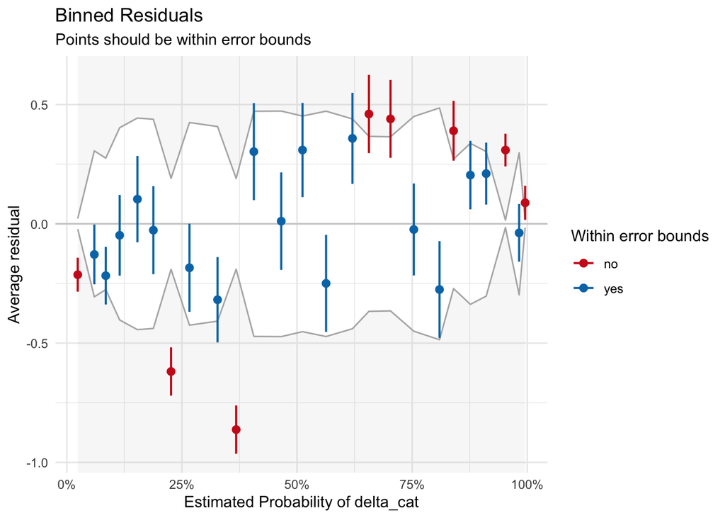

```r
performance::binned_residuals(model_melhora) |> plot()
```

#### 2.2.1.3 Autocorrelação dos resíduos

Independência dos resíduos (Durbin-Watson test).

**Código**

```r
performance::check_autocorrelation(model_melhora)
```

```
OK: Residuals appear to be independent and not autocorrelated (p = 0.070).
```

#### 2.2.1.4 Verificações preditivas posteriores

Simulação de dados replicados sob o modelo ajustado e posterior comparação com os dados observados.

**Código**

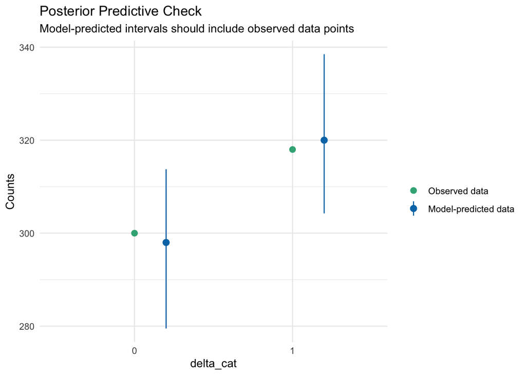

```r
performance::check_predictions(model_melhora) |> plot()
```

#### 2.2.1.5 Qualidade do ajuste do modelo

Teste de Hosmer-Lemeshow para avaliar a qualidade do ajuste de modelos binomiais. P-valor < 0.05 indica que o modelo não ajusta bem os dados.

**Código**

```r
# Teste de Hosmer-Lemeshow pode falhar com poucos eventos de melhora
tryCatch(
    {
        performance::performance_hosmer(model_melhora)
    },
    error = function(e) {
        cat("Aviso: Teste de Hosmer-Lemeshow não pode ser executado.\n")
        cat("Possível causa: poucos eventos de melhora ou falta de variação nas predi<U+00E7><U+00F5>es.\n")
        cat("Erro:", e$message, "\n")
    }
)
```

```
# Hosmer-Lemeshow Goodness-of-Fit Test

  Chi-squared: 18.657
           df:  8
      p-value:  0.017
```

#### 2.2.1.6 Colinearidade

Verificação de colinearidade entre as variáveis independentes (*Variance Inflation Factor*). Valores maiores que 10 indicam colinearidade entre as variáveis.

**Código**

```r
performance::check_collinearity(model_melhora) |>
    arrange(desc(VIF)) |>
    select(Term, VIF, VIF_CI_low, VIF_CI_high) |>
    performance::print_html()
```

| Term | VIF | VIF_CI_low | VIF_CI_high |
| --- | --- | --- | --- |
| lenke | 2.45 | 2.18 | 2.78 |
| escoliometro_maior_10_graus | 2.33 | 2.08 | 2.64 |
| risser | 2.22 | 1.98 | 2.51 |
| idade | 1.90 | 1.71 | 2.14 |
| cifose_toracica | 1.45 | 1.33 | 1.62 |
| lordose_lombar | 1.35 | 1.24 | 1.50 |
| sexo | 1.24 | 1.15 | 1.38 |
| correcao_colete | 1.15 | 1.08 | 1.29 |
| imc | 1.13 | 1.06 | 1.27 |
| flexibilidade | 1.12 | 1.06 | 1.27 |

**Código**

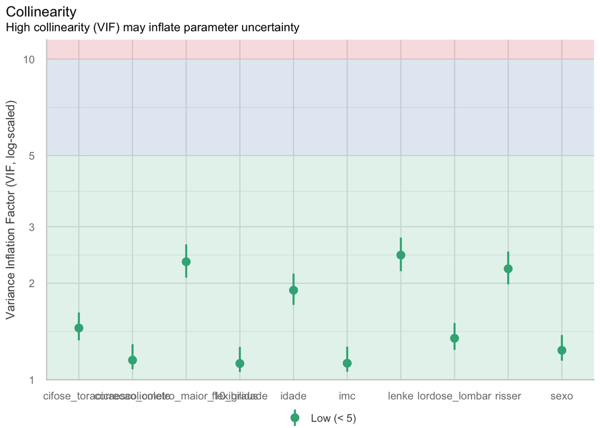

```r
performance::check_collinearity(model_melhora) |> plot()
```

#### 2.2.1.7 Outliers

**Código**

```r
performance::check_outliers(model_melhora)
```

```
OK: No outliers detected.
- Based on the following method and threshold: cook (0.9).
- For variable: (Whole model)
```

**Código**

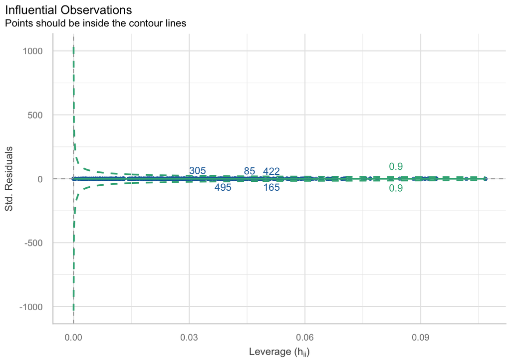

```r
performance::check_outliers(model_melhora) |> plot()
```

#### 2.2.1.8 Coeficiente de determinação (Tjur)

Coeficiente de determinação de Tjur ($R^2_{Tjur}$). Teste específico para modelos binomiais.

**Código**

```r
performance::r2(model_melhora)
```

```
# R2 for Logistic Regression
  Tjur's R2: 0.403
```

#### 2.2.1.9 Tamanho amostral efetivo (casos completos)

**Código**

```r
mf_melhora <- model.frame(model_melhora)
n_melhora <- nrow(mf_melhora)
eventos_melhora <- sum(mf_melhora[[1]] == 1, na.rm = TRUE)
sem_melhora <- sum(mf_melhora[[1]] == 0, na.rm = TRUE)
tibble(
    n_modelo = n_melhora,
    eventos_melhora = eventos_melhora,
    sem_melhora = sem_melhora
)
```

| n_modelo | eventos_melhora | sem_melhora |
| --- | --- | --- |
| 618 | 318 | 300 |

### 2.2.2 Modelo CART (Árvore de Decisão)

**Objetivo:** Identificar perfis de pacientes com maior probabilidade de melhora clínica através de árvores de decisão.

**Disclaimer:** Resultados de modelos CART requerem validação externa. Análise baseada em validação cruzada.

#### 2.2.2.1 Setup e preparação dos dados

**Código**

```r
# =============================================================================
# MODELO 1: CART - PREPARAÇÃO DOS DADOS
# =============================================================================

# Carregamento de bibliotecas específicas para machine learning
library(tidymodels) # framework tidyverse para ML
library(rpart.plot) # visualização de árvores
library(vip) # importância de variáveis

set.seed(123) # reprodutibilidade

# Preparação do dataset para CART
# Recodificação do desfecho para labels descritivos
df_cart <- df |>
    mutate(
        delta_cat_cart = factor(
            delta_cat,
            levels = c(0, 1),
            labels = c("nao_melhora", "melhora")
        )
    ) |>
    # Seleção das mesmas variáveis dos modelos parametricos
    select(
        delta_cat_cart, # desfecho recodificado

        # Variáveis preditoras numéricas
        idade,
        imc,
        cifose_toracica,
        lordose_lombar,
        correcao_colete,

        # Variáveis preditoras categóricas
        sexo,
        lenke,
        risser,
        flexibilidade,
        escoliometro_maior_10_graus
    )

# Verificação: evento de interesse = "melhora" (segundo nível)
levels(df_cart$delta_cat_cart)
```

```
[1] "nao_melhora" "melhora"
```

#### 2.2.2.2 Recipe (pre-processamento)

O pre-processamento é feito **dentro do resampling** (evita leakage):

- `step_zv()`: remove variáveis com variância zero
- `step_unknown()` + `step_novel()`: robustez a níveis novos/raros durante CV
- `step_impute_median()` + `step_impute_mode()`: imputação de missings

**Código**

```r
cart_rec <- recipe(delta_cat_cart ~ ., data = df_cart) |>
    step_zv(all_predictors()) |>
    step_unknown(all_nominal_predictors()) |>
    step_novel(all_nominal_predictors()) |>
    step_impute_median(all_numeric_predictors()) |>
    step_impute_mode(all_nominal_predictors())

cart_rec
```

#### 2.2.2.3 Modelo e hiperparâmetros

Hiperparâmetros do modelo CART:

- **`cost_complexity` (cp)**: controla poda/complexidade do modelo.
- **`tree_depth`**: limita profundidade (3-5 níveis).
- **`min_n`**: mínimo de observações por nó terminal (15-40).

**Código**

```r
cart_spec <- decision_tree(
    cost_complexity = tune(),
    tree_depth = tune(),
    min_n = tune()
) |>
    set_engine("rpart") |>
    set_mode("classification")

cart_wf <- workflow() |>
    add_recipe(cart_rec) |>
    add_model(cart_spec)

cart_wf
```

```
══ Workflow ════════════════════════════════════════════════════════════════════
Preprocessor: Recipe
Model: decision_tree()

── Preprocessor ────────────────────────────────────────────────────────────────
5 Recipe Steps

• step_zv()
• step_unknown()
• step_novel()
• step_impute_median()
• step_impute_mode()

── Model ───────────────────────────────────────────────────────────────────────
Decision Tree Model Specification (classification)

Main Arguments:
  cost_complexity = tune()
  tree_depth = tune()
  min_n = tune()

Computational engine: rpart
```

#### 2.2.2.4 Validação cruzada e tuning

Usamos **CV estratificada repetida** (10-fold, 5 repetições) para estimar desempenho e selecionar hiperparâmetros.

**Código**

```r
set.seed(123)
folds <- vfold_cv(df_cart, v = 10, repeats = 5, strata = delta_cat_cart)

# Metricas de interesse
metricas <- metric_set(roc_auc, accuracy, sens, spec)

# Grid de hiperparametros
set.seed(123)
cart_grid <- grid_latin_hypercube(
    cost_complexity(range = c(-4, -2)), # menos poda extrema
    tree_depth(range = c(3L, 5L)), # árvores menos profundas
    min_n(range = c(15L, 40L)), # mínimo mais alto por nó
    size = 30
)

# Tuning
set.seed(123)
cart_tuned <- tune_grid(
    cart_wf,
    resamples = folds,
    grid = cart_grid,
    metrics = metricas,
    control = control_grid(save_pred = TRUE)
)
```

#### 2.2.2.5 Melhores hiperparâmetros

Selecionamos pelo **maior AUC ROC medio** na CV:

**Código**

```r
# Top 10 combinacoes por AUC
cart_tuned |>
    collect_metrics() |>
    filter(.metric == "roc_auc") |>
    arrange(desc(mean)) |>
    slice_head(n = 10)
```

| cost_complexity | tree_depth | min_n | .metric | .estimator | mean | n | std_err | .config |
| --- | --- | --- | --- | --- | --- | --- | --- | --- |
| 0.0001246367 | 5 | 23 | roc_auc | binary | 0.8138172 | 50 | 0.007404566 | pre0_mod02_post0 |
| 0.0001853946 | 5 | 18 | roc_auc | binary | 0.8130823 | 50 | 0.006777569 | pre0_mod05_post0 |
| 0.0005542776 | 5 | 22 | roc_auc | binary | 0.8125998 | 50 | 0.007272953 | pre0_mod12_post0 |
| 0.0043892119 | 5 | 19 | roc_auc | binary | 0.8091418 | 50 | 0.007274896 | pre0_mod25_post0 |
| 0.0008086454 | 5 | 38 | roc_auc | binary | 0.8066946 | 50 | 0.006904476 | pre0_mod14_post0 |
| 0.0002748431 | 5 | 37 | roc_auc | binary | 0.8066878 | 50 | 0.006997592 | pre0_mod07_post0 |
| 0.0052593835 | 5 | 23 | roc_auc | binary | 0.8058599 | 50 | 0.007433870 | pre0_mod26_post0 |
| 0.0005106259 | 4 | 25 | roc_auc | binary | 0.8018448 | 50 | 0.007244576 | pre0_mod11_post0 |
| 0.0003521931 | 4 | 21 | roc_auc | binary | 0.8010554 | 50 | 0.007271750 | pre0_mod09_post0 |
| 0.0018779820 | 4 | 25 | roc_auc | binary | 0.8003884 | 50 | 0.007405393 | pre0_mod20_post0 |

**Código**

```r
# Melhor combinacao
best_params <- cart_tuned |>
    select_best(metric = "roc_auc")

best_params
```

| cost_complexity | tree_depth | min_n | .config |
| --- | --- | --- | --- |
| 0.0001246367 | 5 | 23 | pre0_mod02_post0 |

#### 2.2.2.6 Desempenho final (CV)

Avaliamos o modelo finalizado com os melhores hiperparâmetros:

**Código**

```r
cart_final_wf <- finalize_workflow(cart_wf, best_params)

set.seed(123)
cart_res <- fit_resamples(
    cart_final_wf,
    resamples = folds,
    metrics = metricas,
    control = control_resamples(save_pred = TRUE)
)

# Metricas agregadas (media e SD)
cart_metrics <- cart_res |>
    collect_metrics() |>
    select(.metric, mean, std_err, n) |>
    mutate(
        ci_lower = mean - 1.96 * std_err,
        ci_upper = mean + 1.96 * std_err
    )

cart_metrics
```

| .metric | mean | std_err | n | ci_lower | ci_upper |
| --- | --- | --- | --- | --- | --- |
| accuracy | 0.7458628 | 0.008077097 | 50 | 0.7300317 | 0.7616939 |
| roc_auc | 0.8138172 | 0.007404566 | 50 | 0.7993043 | 0.8283302 |
| sens | 0.7573978 | 0.014532785 | 50 | 0.7289136 | 0.7858821 |
| spec | 0.7350000 | 0.013340373 | 50 | 0.7088529 | 0.7611471 |

#### 2.2.2.7 Métricas por fold (dispersão)

Visualização da incerteza nas estimativas de desempenho:

**Código**

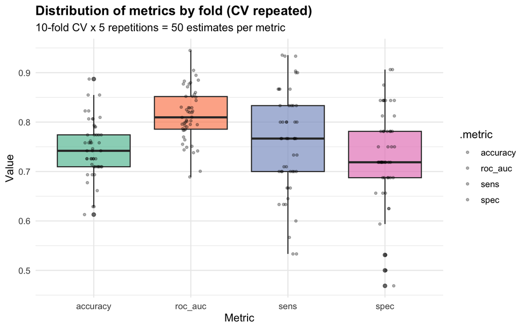

```r
cart_res |>
    collect_metrics(summarize = FALSE) |>
    ggplot(aes(x = .metric, y = .estimate, fill = .metric)) +
    geom_boxplot(alpha = 0.7, show.legend = FALSE) +
    geom_jitter(width = 0.1, alpha = 0.3, size = 1) +
    scale_fill_brewer(palette = "Set2") +
    labs(
        title = "Distribution of metrics by fold (CV repeated)",
        subtitle = "10-fold CV x 5 repetitions = 50 estimates per metric",
        x = "Metric",
        y = "Value"
    ) +
    theme_minimal(base_size = 12) +
    theme(
        plot.title = element_text(face = "bold"),
        axis.text.x = element_text(angle = 0)
    )
```

#### 2.2.2.8 Matriz de confusão agregada (normalizada)

**Código**

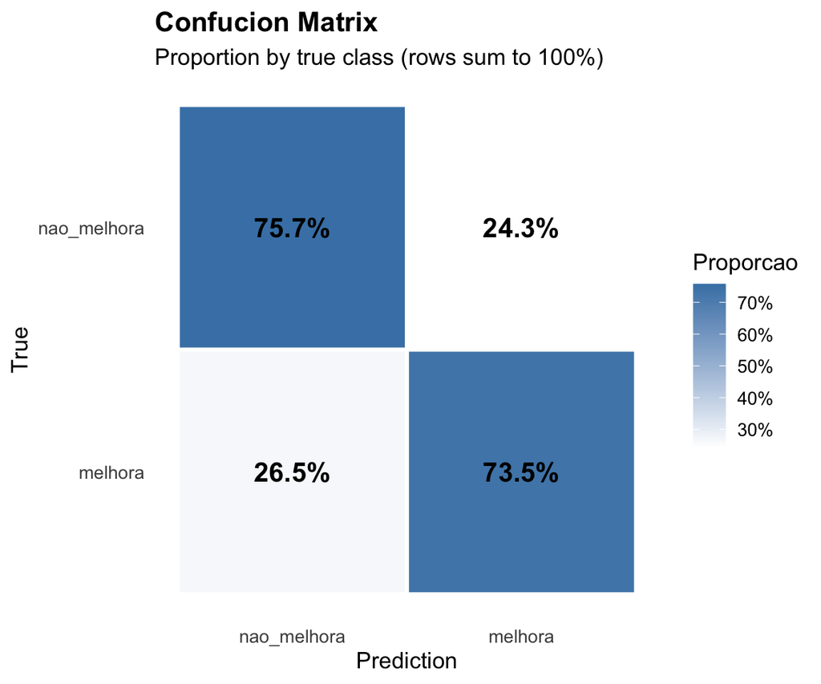

```r
# Predicoes agregadas de todos os folds
preds_all <- cart_res |>
    collect_predictions()

# Matriz de confusao
conf_mat_data <- preds_all |>
    conf_mat(truth = delta_cat_cart, estimate = .pred_class)

# Normalizar por linha (proporcao por classe verdadeira)
conf_mat_tbl <- conf_mat_data$table |>
    as.data.frame() |>
    group_by(Truth) |>
    mutate(
        prop = Freq / sum(Freq),
        label = scales::percent(prop, accuracy = 0.1)
    ) |>
    ungroup()

# Visualizacao heatmap normalizado
ggplot(conf_mat_tbl, aes(x = Prediction, y = Truth, fill = prop)) +
    geom_tile(color = "white", linewidth = 1) +
    geom_text(aes(label = label), size = 5, fontface = "bold") +
    scale_fill_gradient(
        low = "white",
        high = "steelblue",
        labels = scales::percent,
        name = "Proporcao"
    ) +
    scale_y_discrete(limits = rev) +
    labs(
        title = "Confucion Matrix",
        subtitle = "Proportion by true class (rows sum to 100%)",
        x = "Prediction",
        y = "True"
    ) +
    theme_minimal(base_size = 12) +
    theme(
        plot.title = element_text(face = "bold"),
        panel.grid = element_blank()
    )
```

#### 2.2.2.9 Árvore final

Ajustamos o modelo final no dataset completo para visualização e interpretação:

**Código**

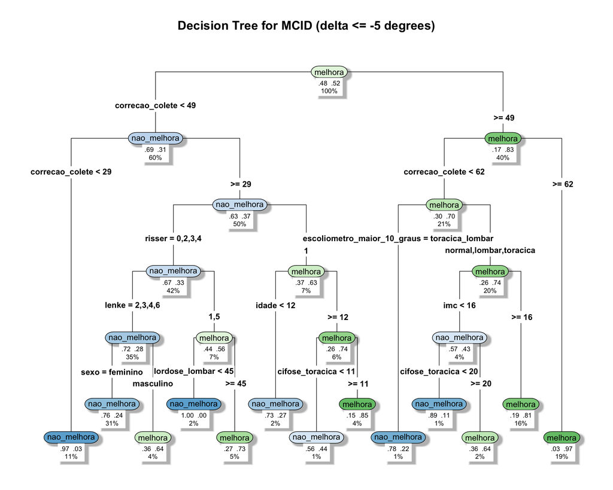

```r
cart_fit_full <- fit(cart_final_wf, data = df_cart)
cart_rpart <- extract_fit_engine(cart_fit_full)

# Plot da arvore com rpart.plot
rpart.plot(
    cart_rpart,
    type = 4,
    extra = 104,
    under = TRUE,
    fallen.leaves = TRUE,
    roundint = FALSE,
    box.palette = "BuGn",
    shadow.col = "gray",
    main = "Decision Tree for MCID (delta <= -5 degrees)"
)
```

#### 2.2.2.10 Importância de variáveis

**Código**

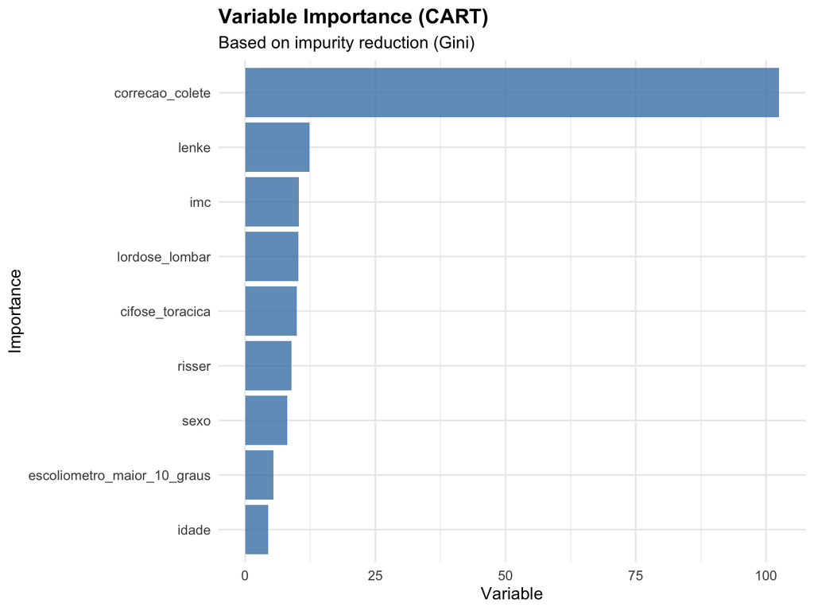

```r
# Grafico de importancia com vip
cart_fit_full |>
    extract_fit_parsnip() |>
    vip(
        num_features = 15,
        geom = "col",
        aesthetics = list(fill = "steelblue", alpha = 0.8)
    ) +
    labs(
        title = "Variable Importance (CART)",
        subtitle = "Based on impurity reduction (Gini)",
        x = "Importance",
        y = "Variable"
    ) +
    theme_minimal(base_size = 12) +
    theme(plot.title = element_text(face = "bold"))
```

#### 2.2.2.11 Análise de estabilidade (Bootstrap)

**Código**

```r
# Função para extrair variáveis de split principais de uma árvore (únicas por árvore)
extract_main_splits <- function(rpart_model, max_levels = 3) {
    frame <- rpart_model$frame
    # Filtrar apenas nós internos (não folhas)
    internal_nodes <- frame[frame$var != "<leaf>", ]

    # Extrair apenas as variáveis (não os valores de corte)
    if (nrow(internal_nodes) > 0) {
        # Limitar aos primeiros níveis (mais estáveis)
        rownames_numeric <- as.numeric(rownames(internal_nodes))
        main_splits <- internal_nodes[rownames_numeric <= (2^max_levels - 1), ]
        # Retornar apenas variáveis ÚNICAS por árvore
        return(unique(main_splits$var))
    } else {
        return(character(0))
    }
}

# Bootstrap para verificar consistência dos splits
set.seed(123)
n_bootstrap <- 100
bootstrap_splits <- list()

for (i in 1:n_bootstrap) {
    # Amostra bootstrap
    boot_sample <- df_cart[sample(nrow(df_cart), replace = TRUE), ]

    # Ajustar modelo com mesmos hiperparâmetros
    boot_model <- decision_tree(
        cost_complexity = best_params$cost_complexity,
        tree_depth = best_params$tree_depth,
        min_n = best_params$min_n
    ) |>
        set_engine("rpart") |>
        set_mode("classification") |>
        fit(delta_cat_cart ~ ., data = boot_sample)

    # Extrair splits principais
    boot_rpart <- extract_fit_engine(boot_model)
    bootstrap_splits[[i]] <- extract_main_splits(boot_rpart)
}

# Análise de estabilidade
main_vars_stability <- table(unlist(bootstrap_splits))
stability_summary <- sort(main_vars_stability / n_bootstrap, decreasing = TRUE)

cat("Estabilidade das variáveis nos primeiros splits (% de árvores que usam cada variável):\n")
```

```
Estabilidade das variáveis nos primeiros splits (% de árvores que usam cada variável):
```

**Código**

```r
print(round(stability_summary * 100, 1))
```

```
            correcao_colete                      risser
                        100                          75
                        imc             cifose_toracica
                         43                          35
                      lenke                       idade
                         29                          21
             lordose_lombar escoliometro_maior_10_graus
                         18                          15
                       sexo               flexibilidade
                          8                           2
```

#### 2.2.2.12 Tabela de folhas (grupos de predicao)

Esta tabela mostra os **nós terminais** (folhas) da árvore, com as regras que definem cada grupo, o tamanho do grupo e a proporção de melhora:

**Código**

```r
# Extrair informacoes dos nos terminais
frame <- cart_rpart$frame
leaves_idx <- which(frame$var == "<leaf>")

# Funcao para extrair regras de cada no
get_path_rules <- function(tree, node_id) {
    path <- rpart::path.rpart(tree, nodes = node_id, print.it = FALSE)
    rules <- path[[1]][-1] # remover "root"
    if (length(rules) == 0) {
        return("(raiz)")
    }
    paste(rules, collapse = " E ")
}

# Construir tabela de folhas
leaves_tbl <- tibble(
    no = as.integer(rownames(frame)[leaves_idx]),
    n = frame$n[leaves_idx],
    n_melhora = frame$n[leaves_idx] * frame$yval2[leaves_idx, 5],
    n_nao_melhora = frame$n[leaves_idx] * frame$yval2[leaves_idx, 4],
    prop_melhora = frame$yval2[leaves_idx, 5],
    predicao = ifelse(frame$yval[leaves_idx] == 2, "melhora", "nao_melhora")
) |>
    rowwise() |>
    mutate(regras = get_path_rules(cart_rpart, no)) |>
    ungroup() |>
    mutate(
        prop_melhora_pct = scales::percent(prop_melhora, accuracy = 0.1),
        grupo = paste0("Grupo ", row_number())
    ) |>
    select(grupo, predicao, n, prop_melhora_pct, regras) |>
    arrange(desc(predicao), desc(n))

leaves_tbl |>
    rename(
        Grupo = grupo,
        Predicao = predicao,
        N = n,
        `% Melhora` = prop_melhora_pct,
        Regras = regras
    ) |>
    knitr::kable(align = c("l", "l", "r", "r", "l"))
```

| Grupo | Predicao | N | % Melhora | Regras |
| --- | --- | --- | --- | --- |
| Grupo 2 | nao_melhora | 195 | 23.6% | correcao_colete< 49.42 E correcao_colete>=29.45 E risser=0,2,3,4 E lenke=2,3,4,6 E sexo=feminino |
| Grupo 1 | nao_melhora | 66 | 3.0% | correcao_colete< 49.42 E correcao_colete< 29.45 |
| Grupo 6 | nao_melhora | 11 | 27.3% | correcao_colete< 49.42 E correcao_colete>=29.45 E risser=1 E idade< 11.5 |
| Grupo 4 | nao_melhora | 10 | 0.0% | correcao_colete< 49.42 E correcao_colete>=29.45 E risser=0,2,3,4 E lenke=1,5 E lordose_lombar< 45 |
| Grupo 7 | nao_melhora | 9 | 44.4% | correcao_colete< 49.42 E correcao_colete>=29.45 E risser=1 E idade>=11.5 E cifose_toracica< 11 |
| Grupo 9 | nao_melhora | 9 | 22.2% | correcao_colete>=49.42 E correcao_colete< 61.72 E escoliometro_maior_10_graus=toracica_lombar |
| Grupo 10 | nao_melhora | 9 | 11.1% | correcao_colete>=49.42 E correcao_colete< 61.72 E escoliometro_maior_10_graus=normal,lombar,toracica E imc< 15.84 E cifose_toracica< 19.5 |
| Grupo 13 | melhora | 115 | 96.5% | correcao_colete>=49.42 E correcao_colete>=61.72 |
| Grupo 12 | melhora | 99 | 80.8% | correcao_colete>=49.42 E correcao_colete< 61.72 E escoliometro_maior_10_graus=normal,lombar,toracica E imc>=15.84 |
| Grupo 5 | melhora | 33 | 72.7% | correcao_colete< 49.42 E correcao_colete>=29.45 E risser=0,2,3,4 E lenke=1,5 E lordose_lombar>=45 |
| Grupo 8 | melhora | 26 | 84.6% | correcao_colete< 49.42 E correcao_colete>=29.45 E risser=1 E idade>=11.5 E cifose_toracica>=11 |
| Grupo 3 | melhora | 25 | 64.0% | correcao_colete< 49.42 E correcao_colete>=29.45 E risser=0,2,3,4 E lenke=2,3,4,6 E sexo=masculino |
| Grupo 11 | melhora | 14 | 64.3% | correcao_colete>=49.42 E correcao_colete< 61.72 E escoliometro_maior_10_graus=normal,lombar,toracica E imc< 15.84 E cifose_toracica>=19.5 |

#### 2.2.2.13 Curva ROC

**Código**

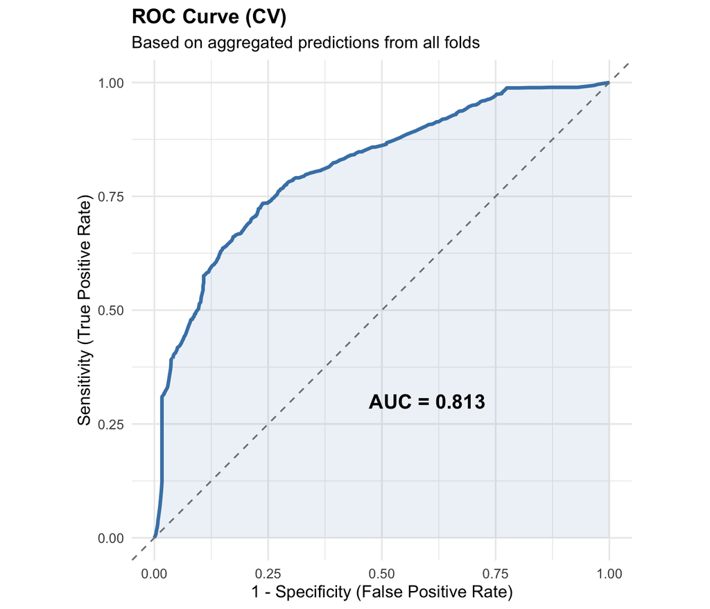

```r
# Curva ROC a partir das predicoes CV
roc_data <- preds_all |>
    roc_curve(truth = delta_cat_cart, .pred_melhora, event_level = "second")

# AUC para o titulo
auc_val <- preds_all |>
    roc_auc(truth = delta_cat_cart, .pred_melhora, event_level = "second") |>
    pull(.estimate)

ggplot(roc_data, aes(x = 1 - specificity, y = sensitivity)) +
    geom_path(linewidth = 1.2, color = "steelblue") +
    geom_abline(linetype = "dashed", color = "gray50") +
    geom_ribbon(
        aes(ymin = 0, ymax = sensitivity),
        alpha = 0.1,
        fill = "steelblue"
    ) +
    annotate(
        "text",
        x = 0.6,
        y = 0.3,
        label = paste0("AUC = ", round(auc_val, 3)),
        size = 5,
        fontface = "bold"
    ) +
    labs(
        title = "ROC Curve (CV)",
        subtitle = "Based on aggregated predictions from all folds",
        x = "1 - Specificity (False Positive Rate)",
        y = "Sensitivity (True Positive Rate)"
    ) +
    coord_equal() +
    theme_minimal(base_size = 12) +
    theme(plot.title = element_text(face = "bold"))
```

## 2.3 Desfecho Binário: Progressão Clínica

Análise da **progressão clínica**, definida como piora ≥ 5 graus na maior curva ($\Delta \ge +5°$).

### 2.3.1 Modelo Logístico

Estima associações ajustadas com a **chance de progressão clínica**, definida como $\Delta \ge +5°$.

**Código**

```r
# =============================================================================
# MODELO LOGÍSTICO - PROGRESS<U+00C3>O CLÍNICA
# =============================================================================

# Modelo para chance de progressão clínica (delta ≥ +5°)
# Utiliza as mesmas variáveis dos outros modelos

model_progressao <- glm(
    delta_progression ~
        # Variáveis numéricas
        idade + # idade do paciente
        imc + # índice de massa corporal
        cifose_toracica + # ângulo da cifose torácica
        lordose_lombar + # ângulo da lordose lombar
        correcao_colete + # percentual de correção com colete

        # Variáveis categóricas
        sexo + # sexo do paciente
        lenke + # classificação de Lenke
        risser + # sinal de Risser
        flexibilidade + # flexibilidade da curva
        escoliometro_maior_10_graus, # região com gibosidade > 10°
    data = df,
    family = "binomial" # distribuição binomial para regressão logística
)
```

#### 2.3.1.1 Parâmetros do modelo

Parâmetros do modelo de regressão logística. Resposta em *Odds Ratio*.

**Código**

```r
model_progressao |>
    gtsummary::tbl_regression(exponentiate = TRUE, conf.level = 0.95) |>
    gtsummary::bold_p() |>
    gtsummary::bold_labels() |>
    gtsummary::italicize_levels()
```

| **Characteristic** | **OR** | **95% CI** | **p-value** |
| --- | --- | --- | --- |
| idade | 0.85 | 0.56, 1.29 | 0.4 |
| imc | 1.10 | 0.91, 1.31 | 0.3 |
| cifose_toracica | 0.90 | 0.83, 0.96 | 0.003 |
| lordose_lombar | 1.01 | 0.95, 1.06 | 0.8 |
| correcao_colete | 0.96 | 0.92, 0.99 | 0.033 |
| sexo |  |  |  |
| feminino | — | — |  |
| masculino | 3.53 | 0.53, 21.7 | 0.2 |
| lenke |  |  |  |
| 1 | — | — |  |
| 2 | 1.30 | 0.08, 39.4 | 0.9 |
| 3 | 1.17 | 0.14, 26.6 | >0.9 |
| 4 | 3.29 | 0.35, 79.0 | 0.4 |
| 5 | 0.00 | 0.00, 419,627,348,273,439,586,821,317,894,482,929,123,328 | >0.9 |
| 6 | 0.11 | 0.00, 3.82 | 0.2 |
| risser |  |  |  |
| 0 | — | — |  |
| 1 | 0.35 | 0.07, 1.43 | 0.2 |
| 2 | 0.08 | 0.01, 0.42 | 0.006 |
| 3 | 0.00 | 0.00, 4,840,904,359,509,076 | >0.9 |
| 4 | 0.24 | 0.03, 1.31 | 0.12 |
| flexibilidade |  |  |  |
| flexivel | — | — |  |
| rigido | 3.35 | 1.08, 11.9 | 0.046 |
| escoliometro_maior_10_graus |  |  |  |
| normal | — | — |  |
| lombar | 0.96 | 0.03, 17.2 | >0.9 |
| toracica | 0.94 | 0.21, 5.33 | >0.9 |
| toracica_lombar | 7.49 | 1.10, 62.8 | 0.046 |

Abbreviations: CI = Confidence Interval, OR = Odds Ratio

#### 2.3.1.2 Resíduos binarizados

**Código**

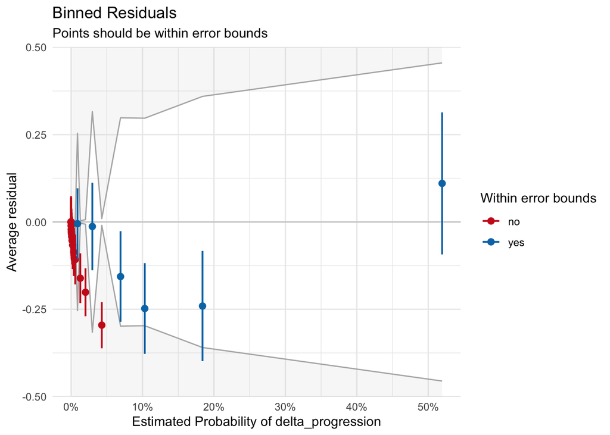

```r
performance::binned_residuals(model_progressao) |> plot()
```

#### 2.3.1.3 Autocorrelação dos resíduos

Independência dos resíduos (Durbin-Watson test).

**Código**

```r
performance::check_autocorrelation(model_progressao)
```

```
OK: Residuals appear to be independent and not autocorrelated (p = 0.786).
```

#### 2.3.1.4 Verificações preditivas posteriores

Simulação de dados replicados sob o modelo ajustado e posterior comparação com os dados observados.

**Código**

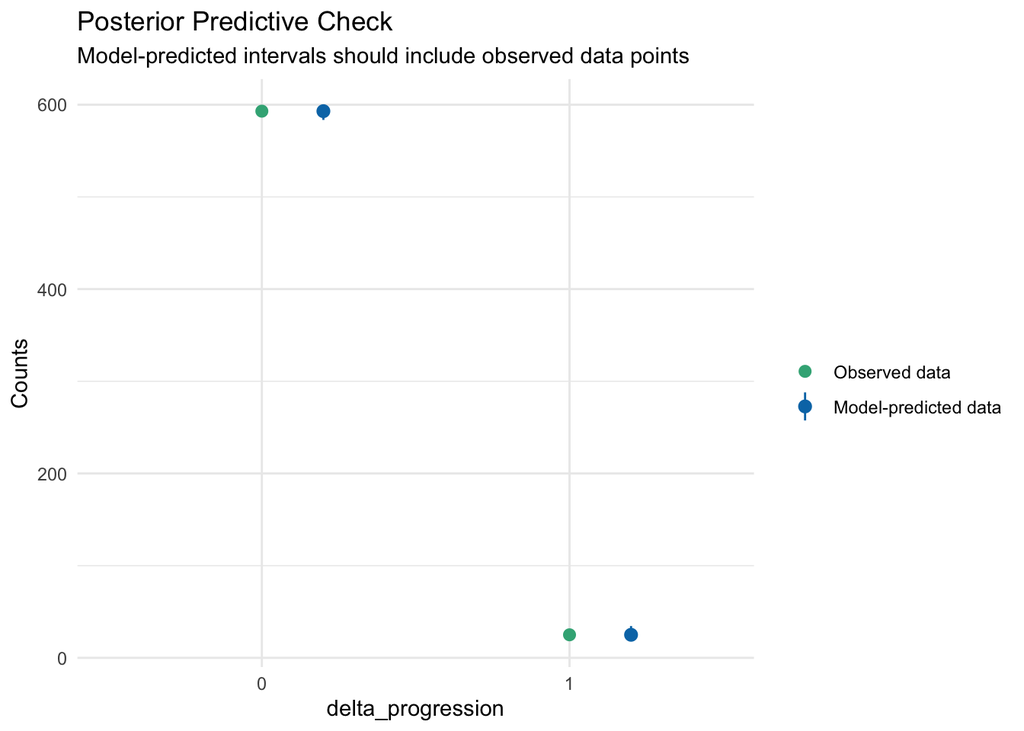

```r
performance::check_predictions(model_progressao) |> plot()
```

#### 2.3.1.5 Qualidade do ajuste do modelo

Teste de Hosmer-Lemeshow para avaliar a qualidade do ajuste de modelos binomiais. P-valor < 0.05 indica que o modelo não ajusta bem os dados.

**Código**

```r
# Teste de Hosmer-Lemeshow pode falhar com poucos eventos de progressão
tryCatch(
    {
        performance::performance_hosmer(model_progressao)
    },
    error = function(e) {
        cat("Aviso: Teste de Hosmer-Lemeshow não pode ser executado.\n")
        cat("Possível causa: poucos eventos de progressão ou falta de variação nas predições.\n")
        cat("Erro:", e$message, "\n")
    }
)
```

```
# Hosmer-Lemeshow Goodness-of-Fit Test

  Chi-squared: 1.030
           df: 8
      p-value: 0.998
```

#### 2.3.1.6 Colinearidade

Verificação de colinearidade entre as variáveis independentes (*Variance Inflation Factor*). Valores maiores que 10 indicam colinearidade entre as variáveis.

**Código**

```r
performance::check_collinearity(model_progressao) |>
    arrange(desc(VIF)) |>
    select(Term, VIF, VIF_CI_low, VIF_CI_high) |>
    performance::print_html()
```

| Term | VIF | VIF_CI_low | VIF_CI_high |
| --- | --- | --- | --- |
| lenke | 3.89 | 3.42 | 4.45 |
| escoliometro_maior_10_graus | 3.32 | 2.93 | 3.79 |
| risser | 2.45 | 2.18 | 2.78 |
| idade | 2.12 | 1.90 | 2.40 |
| cifose_toracica | 1.58 | 1.43 | 1.77 |
| sexo | 1.58 | 1.43 | 1.76 |
| lordose_lombar | 1.49 | 1.36 | 1.66 |
| flexibilidade | 1.34 | 1.23 | 1.49 |
| imc | 1.25 | 1.16 | 1.39 |
| correcao_colete | 1.23 | 1.14 | 1.38 |

**Código**

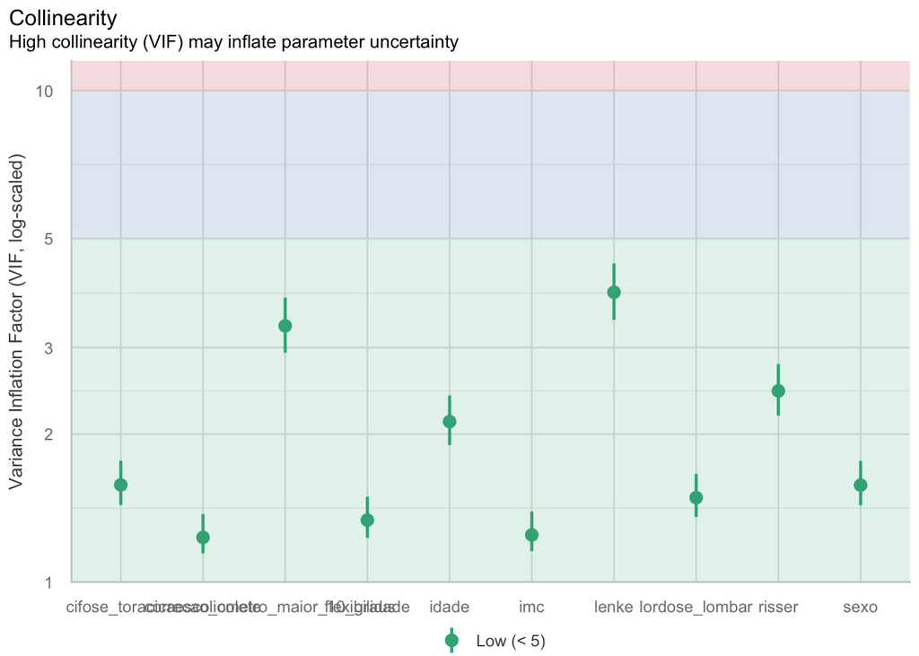

```r
performance::check_collinearity(model_progressao) |> plot()
```

#### 2.3.1.7 Outliers

**Código**

```r
performance::check_outliers(model_progressao)
```

```
OK: No outliers detected.
- Based on the following method and threshold: cook (0.9).
- For variable: (Whole model)
```

**Código**

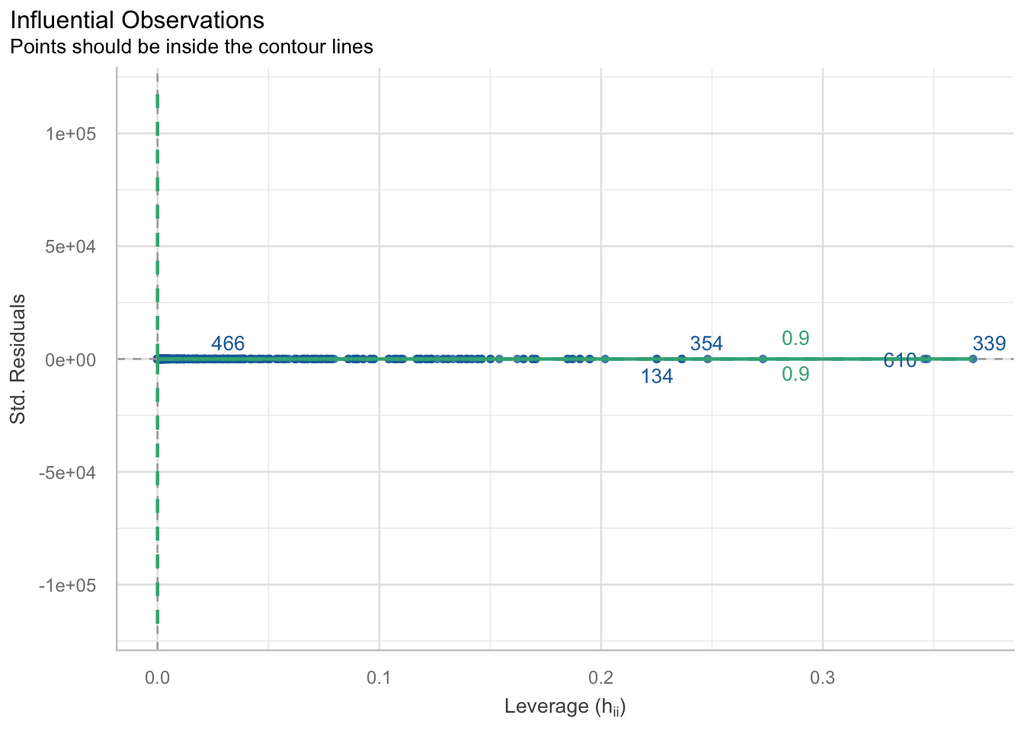

```r
performance::check_outliers(model_progressao) |> plot()
```

#### 2.3.1.8 Coeficiente de determinação (Tjur)

Coeficiente de determinação de Tjur ($R^2_{Tjur}$). Teste específico para modelos binomiais.

**Código**

```r
performance::r2(model_progressao)
```

```
# R2 for Logistic Regression
  Tjur's R2: 0.345
```

#### 2.3.1.9 Tamanho amostral efetivo (casos completos)

**Código**

```r
mf_progressao <- model.frame(model_progressao)
n_progressao <- nrow(mf_progressao)
eventos_progressao <- sum(mf_progressao[[1]] == 1, na.rm = TRUE)
sem_progressao <- sum(mf_progressao[[1]] == 0, na.rm = TRUE)
tibble(
    n_modelo = n_progressao,
    eventos_progressao = eventos_progressao,
    sem_progressao = sem_progressao
)
```

| n_modelo | eventos_progressao | sem_progressao |
| --- | --- | --- |
| 618 | 25 | 593 |

### 2.3.2 Modelo CART (Árvore de Decisão)

**Objetivo:** Identificar perfis de pacientes com maior probabilidade de progressão clínica através de árvores de decisão.

**Disclaimer:** Resultados de modelos CART requerem validação externa. Análise baseada em validação cruzada.

#### 2.3.2.1 Setup e preparação dos dados

**Código**

```r
# =============================================================================
# CART - PROGRESS<U+00C3>O CLÍNICA: PREPARAÇÃO DOS DADOS
# =============================================================================

# Carregamento de bibliotecas específicas para machine learning
library(tidymodels) # framework tidyverse para ML
library(rpart.plot) # visualização de árvores
library(vip) # importância de variáveis

set.seed(123) # reprodutibilidade

# Preparação do dataset para CART
# Recodificação do desfecho para labels descritivos
df_cart_progressao <- df |>
    mutate(
        delta_progression_cart = factor(
            delta_progression,
            levels = c(0, 1),
            labels = c("nao_progrediu", "progrediu")
        )
    ) |>
    # Seleção das mesmas variáveis dos modelos parametricos
    select(
        delta_progression_cart, # desfecho recodificado

        # Variáveis preditoras numéricas
        idade,
        imc,
        cifose_toracica,
        lordose_lombar,
        correcao_colete,

        # Variáveis preditoras categóricas
        sexo,
        lenke,
        risser,
        flexibilidade,
        escoliometro_maior_10_graus
    )

# Verificação: evento de interesse = "progrediu" (segundo nível)
levels(df_cart_progressao$delta_progression_cart)
```

```
[1] "nao_progrediu" "progrediu"
```

#### 2.3.2.2 Recipe (pre-processamento)

O pre-processamento é feito **dentro do resampling** (evita leakage):

- `step_zv()`: remove variáveis com variância zero
- `step_unknown()` + `step_novel()`: robustez a níveis novos/raros durante CV
- `step_impute_median()` + `step_impute_mode()`: imputação de missings

**Código**

```r
cart_rec_progressao <- recipe(delta_progression_cart ~ ., data = df_cart_progressao) |>
    step_zv(all_predictors()) |>
    step_unknown(all_nominal_predictors()) |>
    step_novel(all_nominal_predictors()) |>
    step_impute_median(all_numeric_predictors()) |>
    step_impute_mode(all_nominal_predictors())

cart_rec_progressao
```

#### 2.3.2.3 Modelo e hiperparâmetros

Hiperparâmetros do modelo CART:

- **`cost_complexity` (cp)**: controla poda/complexidade do modelo.
- **`tree_depth`**: limita profundidade (3-5 níveis).
- **`min_n`**: mínimo de observações por nó terminal (15-40).

**Código**

```r
cart_spec_progressao <- decision_tree(
    cost_complexity = tune(),
    tree_depth = tune(),
    min_n = tune()
) |>
    set_engine("rpart") |>
    set_mode("classification")

cart_wf_progressao <- workflow() |>
    add_recipe(cart_rec_progressao) |>
    add_model(cart_spec_progressao)

cart_wf_progressao
```

```
══ Workflow ════════════════════════════════════════════════════════════════════
Preprocessor: Recipe
Model: decision_tree()

── Preprocessor ────────────────────────────────────────────────────────────────
5 Recipe Steps

• step_zv()
• step_unknown()
• step_novel()
• step_impute_median()
• step_impute_mode()

── Model ───────────────────────────────────────────────────────────────────────
Decision Tree Model Specification (classification)

Main Arguments:
  cost_complexity = tune()
  tree_depth = tune()
  min_n = tune()

Computational engine: rpart
```

#### 2.3.2.4 Validação cruzada e tuning

Usamos **CV estratificada repetida** (10-fold, 5 repetições) para estimar desempenho e selecionar hiperparâmetros.

**Código**

```r
set.seed(123)
folds_progressao <- vfold_cv(df_cart_progressao, v = 10, repeats = 5, strata = delta_progression_cart)

# Metricas de interesse
metricas <- metric_set(roc_auc, accuracy, sens, spec)

# Grid de hiperparametros
set.seed(123)
cart_grid_progressao <- grid_latin_hypercube(
    cost_complexity(range = c(-4, -2)), # menos poda extrema
    tree_depth(range = c(3L, 5L)), # árvores menos profundas
    min_n(range = c(15L, 40L)), # mínimo mais alto por nó
    size = 30
)

# Tuning
set.seed(123)
cart_tuned_progressao <- tune_grid(
    cart_wf_progressao,
    resamples = folds_progressao,
    grid = cart_grid_progressao,
    metrics = metricas,
    control = control_grid(save_pred = TRUE)
)
```

#### 2.3.2.5 Melhores hiperparâmetros

Selecionamos pelo **maior AUC ROC medio** na CV:

**Código**

```r
# Top 10 combinacoes por AUC
cart_tuned_progressao |>
    collect_metrics() |>
    filter(.metric == "roc_auc") |>
    arrange(desc(mean)) |>
    slice_head(n = 10)
```

| cost_complexity | tree_depth | min_n | .metric | .estimator | mean | n | std_err | .config |
| --- | --- | --- | --- | --- | --- | --- | --- | --- |
| 0.0043892119 | 5 | 19 | roc_auc | binary | 0.6605437 | 50 | 0.02975876 | pre0_mod25_post0 |
| 0.0001853946 | 5 | 18 | roc_auc | binary | 0.6604922 | 50 | 0.03217994 | pre0_mod05_post0 |
| 0.0005542776 | 5 | 22 | roc_auc | binary | 0.6445159 | 50 | 0.02863002 | pre0_mod12_post0 |
| 0.0001139223 | 3 | 16 | roc_auc | binary | 0.6288798 | 50 | 0.02559257 | pre0_mod01_post0 |
| 0.0013947962 | 3 | 16 | roc_auc | binary | 0.6288798 | 50 | 0.02559257 | pre0_mod18_post0 |
| 0.0003521931 | 4 | 21 | roc_auc | binary | 0.6270439 | 50 | 0.02803607 | pre0_mod09_post0 |
| 0.0094089239 | 4 | 21 | roc_auc | binary | 0.6270439 | 50 | 0.02803607 | pre0_mod30_post0 |
| 0.0002265989 | 4 | 20 | roc_auc | binary | 0.6269884 | 50 | 0.02803464 | pre0_mod06_post0 |
| 0.0054215116 | 4 | 17 | roc_auc | binary | 0.6201865 | 50 | 0.02802373 | pre0_mod27_post0 |
| 0.0001246367 | 5 | 23 | roc_auc | binary | 0.6188883 | 50 | 0.02499708 | pre0_mod02_post0 |

**Código**

```r
# Melhor combinacao
best_params_progressao <- cart_tuned_progressao |>
    select_best(metric = "roc_auc")

best_params_progressao
```

| cost_complexity | tree_depth | min_n | .config |
| --- | --- | --- | --- |
| 0.004389212 | 5 | 19 | pre0_mod25_post0 |

#### 2.3.2.6 Desempenho final (CV)

Avaliamos o modelo finalizado com os melhores hiperparâmetros:

**Código**

```r
cart_final_wf_progressao <- finalize_workflow(cart_wf_progressao, best_params_progressao)

set.seed(123)
cart_res_progressao <- fit_resamples(
    cart_final_wf_progressao,
    resamples = folds_progressao,
    metrics = metricas,
    control = control_resamples(save_pred = TRUE)
)

# Metricas agregadas (media e SD)
cart_metrics_progressao <- cart_res_progressao |>
    collect_metrics() |>
    select(.metric, mean, std_err, n) |>
    mutate(
        ci_lower = mean - 1.96 * std_err,
        ci_upper = mean + 1.96 * std_err
    )

cart_metrics_progressao
```

| .metric | mean | std_err | n | ci_lower | ci_upper |
| --- | --- | --- | --- | --- | --- |
| accuracy | 0.9574910 | 0.003841666 | 50 | 0.9499614 | 0.9650207 |
| roc_auc | 0.6605437 | 0.029758763 | 50 | 0.6022166 | 0.7188709 |
| sens | 0.9879365 | 0.003018151 | 50 | 0.9820210 | 0.9938521 |
| spec | 0.2308333 | 0.046002471 | 50 | 0.1406685 | 0.3209982 |

#### 2.3.2.7 Métricas por fold (dispersão)

Variabilidade das métricas entre os folds de validação cruzada.

**Código**

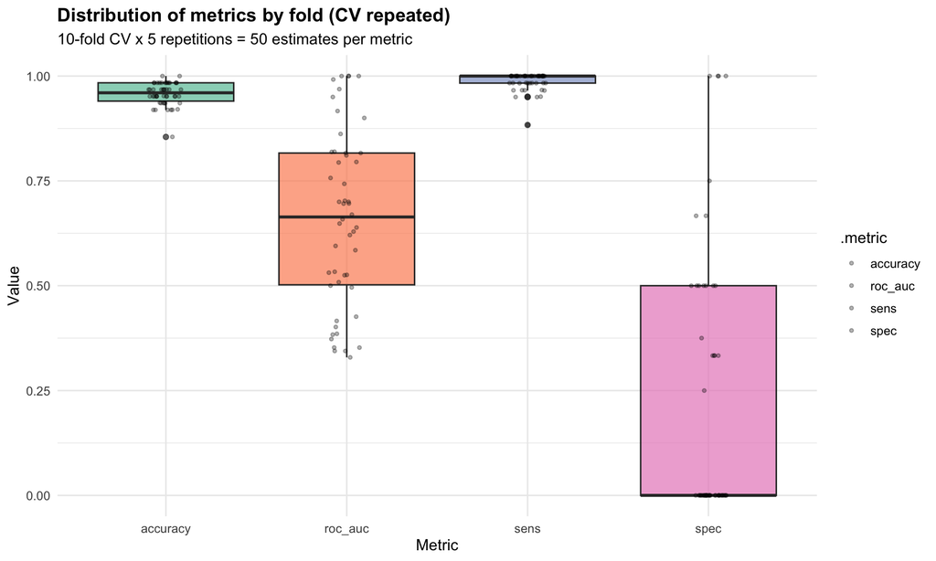

```r
cart_res_progressao |>
    collect_metrics(summarize = FALSE) |>
    ggplot(aes(x = .metric, y = .estimate, fill = .metric)) +
    geom_boxplot(alpha = 0.7, show.legend = FALSE) +
    geom_jitter(width = 0.1, alpha = 0.3, size = 1) +
    scale_fill_brewer(palette = "Set2") +
    labs(
        title = "Distribution of metrics by fold (CV repeated)",
        subtitle = "10-fold CV x 5 repetitions = 50 estimates per metric",
        x = "Metric",
        y = "Value"
    ) +
    theme_minimal(base_size = 12) +
    theme(
        plot.title = element_text(face = "bold"),
        axis.text.x = element_text(angle = 0)
    )
```

#### 2.3.2.8 Matriz de confusão agregada (normalizada)

**Código**

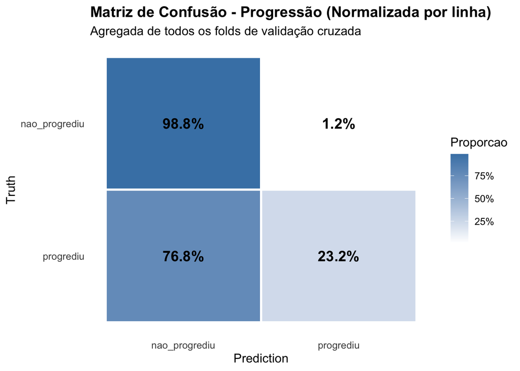

```r
# Matriz de confusão agregada
preds_progressao <- cart_res_progressao |>
    collect_predictions()

# Predicoes agregadas de todos os folds (mantendo fonte de dados do contexto do documento)
preds_all_progressao <- cart_res_progressao |>
    collect_predictions()

# Matriz de confusao
conf_mat_data_progressao <- preds_all_progressao |>
    conf_mat(truth = delta_progression_cart, estimate = .pred_class)

# Normalizar por linha (proporcao por classe verdadeira)
conf_mat_tbl_progressao <- conf_mat_data_progressao$table |>
    as.data.frame() |>
    dplyr::group_by(Truth) |>
    dplyr::mutate(
        prop = Freq / sum(Freq),
        label = scales::percent(prop, accuracy = 0.1)
    ) |>
    dplyr::ungroup()

# Visualizacao heatmap normalizado
ggplot(conf_mat_tbl_progressao, aes(x = Prediction, y = Truth, fill = prop)) +
    geom_tile(color = "white", linewidth = 1) +
    geom_text(aes(label = label), size = 5, fontface = "bold") +
    scale_fill_gradient(
        low = "white",
        high = "steelblue",
        labels = scales::percent,
        name = "Proporcao"
    ) +
    scale_y_discrete(limits = rev) +
    labs(
        title = "Matriz de Confusão - Progressão (Normalizada por linha)",
        subtitle = "Agregada de todos os folds de validação cruzada"
    ) +
    theme_minimal(base_size = 12) +
    theme(
        plot.title = element_text(face = "bold"),
        panel.grid = element_blank()
    )
```

#### 2.3.2.9 Árvore final

Ajustamos o modelo final no dataset completo para visualização e interpretação:

**Código**

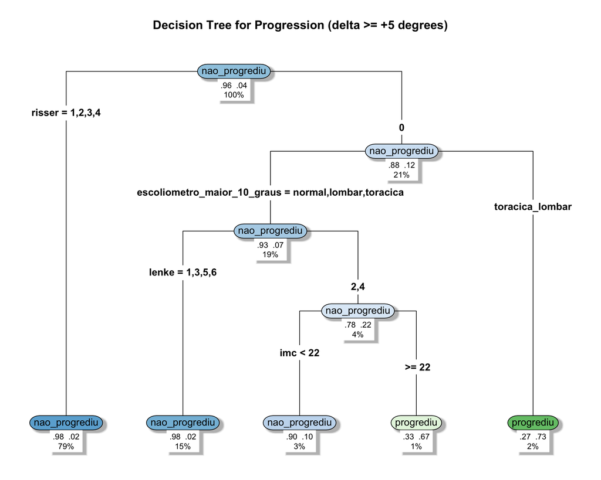

```r
cart_fit_full_progressao <- fit(cart_final_wf_progressao, data = df_cart_progressao)
cart_rpart_progressao <- extract_fit_engine(cart_fit_full_progressao)

# Plot da arvore com rpart.plot
rpart.plot(
    cart_rpart_progressao,
    type = 4,
    extra = 104,
    under = TRUE,
    fallen.leaves = TRUE,
    roundint = FALSE,
    box.palette = "BuGn",
    shadow.col = "gray",
    main = "Decision Tree for Progression (delta >= +5 degrees)"
)
```

#### 2.3.2.10 Importância de variáveis

**Código**

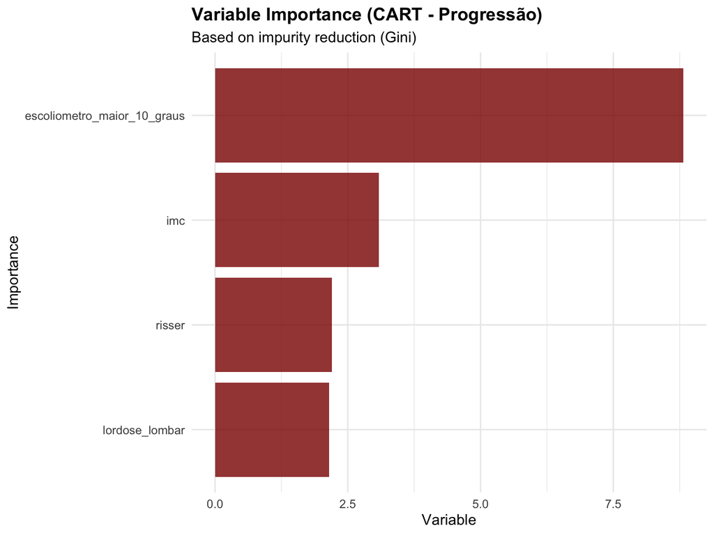

```r
# Verificar se a árvore tem splits antes de calcular importância
tryCatch(
    {
        # Verificar se há splits na árvore
        frame_check <- cart_rpart_progressao$frame
        internal_nodes <- sum(frame_check$var != "<leaf>")

        if (internal_nodes > 0) {
            # Grafico de importancia com vip
            cart_fit_full_progressao |>
                extract_fit_parsnip() |>
                vip(
                    num_features = min(15, internal_nodes),
                    geom = "col",
                    aesthetics = list(fill = "darkred", alpha = 0.8)
                ) +
                labs(
                    title = "Variable Importance (CART - Progressão)",
                    subtitle = "Based on impurity reduction (Gini)",
                    x = "Importance",
                    y = "Variable"
                ) +
                theme_minimal(base_size = 12) +
                theme(plot.title = element_text(face = "bold"))
        } else {
            cat("Aviso: Árvore de progressão não possui splits suficientes para análise de importância.\n")
            cat("Possível causa: poucos eventos de progressão ou parâmetros muito restritivos.\n")

            # Plot informativo
            ggplot() +
                annotate("text",
                    x = 0.5, y = 0.5,
                    label = "Árvore sem splits suficientes\npara análise de importância",
                    size = 6, hjust = 0.5
                ) +
                labs(
                    title = "Variable Importance (CART - Progressão)",
                    subtitle = "Modelo muito simples para análise de importância"
                ) +
                theme_void()
        }
    },
    error = function(e) {
        cat("Erro na análise de importância:", e$message, "\n")
        cat("Possível causa: modelo CART muito simples ou dados insuficientes.\n")
    }
)
```

#### 2.3.2.11 Análise de estabilidade (Bootstrap)

**Código**

```r
# Bootstrap para verificar consistência dos splits
set.seed(123)
n_bootstrap <- 100
bootstrap_splits_progressao <- list()

for (i in 1:n_bootstrap) {
    # Amostra bootstrap
    boot_sample <- df_cart_progressao[sample(nrow(df_cart_progressao), replace = TRUE), ]

    # Ajustar modelo com mesmos hiperparâmetros
    boot_model <- decision_tree(
        cost_complexity = best_params_progressao$cost_complexity,
        tree_depth = best_params_progressao$tree_depth,
        min_n = best_params_progressao$min_n
    ) |>
        set_engine("rpart") |>
        set_mode("classification") |>
        fit(delta_progression_cart ~ ., data = boot_sample)

    # Extrair splits principais
    boot_rpart <- extract_fit_engine(boot_model)
    bootstrap_splits_progressao[[i]] <- extract_main_splits(boot_rpart)
}

# Análise de estabilidade
main_vars_stability_progressao <- table(unlist(bootstrap_splits_progressao))
stability_summary_progressao <- sort(main_vars_stability_progressao / n_bootstrap, decreasing = TRUE)

cat("Estabilidade das variáveis nos primeiros splits (% de árvores que usam cada variável):\n")
```

```
Estabilidade das variáveis nos primeiros splits (% de árvores que usam cada variável):
```

**Código**

```r
print(round(stability_summary_progressao * 100, 1))
```

```
                     risser                       lenke
                         66                          58
escoliometro_maior_10_graus             cifose_toracica
                         54                          31
            correcao_colete                         imc
                         31                          25
                      idade              lordose_lombar
                         12                          12
                       sexo
                          1
```

#### 2.3.2.12 Tabela de folhas (grupos de predicao)

Esta tabela mostra os **nós terminais** (folhas) da árvore, com as regras que definem cada grupo, o tamanho do grupo e a proporção de progressão:

**Código**

```r
# Extrair informacoes dos nos terminais

frame <- cart_rpart_progressao$frame
leaves_idx <- which(frame$var == "<leaf>")

# Funcao para extrair regras de cada no
get_path_rules <- function(tree, node_id) {
    path <- rpart::path.rpart(tree, nodes = node_id, print.it = FALSE)
    rules <- path[[1]][-1] # remover "root"
    if (length(rules) == 0) {
        return("(raiz)")
    }
    paste(rules, collapse = " E ")
}

# Construir tabela de folhas
leaves_tbl <- tibble(
    no = as.integer(rownames(frame)[leaves_idx]),
    n = frame$n[leaves_idx],
    n_melhora = frame$n[leaves_idx] * frame$yval2[leaves_idx, 5],
    n_nao_melhora = frame$n[leaves_idx] * frame$yval2[leaves_idx, 4],
    prop_melhora = frame$yval2[leaves_idx, 5],
    predicao = ifelse(frame$yval[leaves_idx] == 2, "progrediu", "nao_progrediu")
) |>
    rowwise() |>
    mutate(regras = get_path_rules(cart_rpart_progressao, no)) |>
    ungroup() |>
    mutate(
        prop_melhora_pct = scales::percent(prop_melhora, accuracy = 0.1),
        grupo = paste0("Grupo ", row_number())
    ) |>
    select(grupo, predicao, n, prop_melhora_pct, regras) |>
    arrange(desc(predicao), desc(n))

leaves_tbl |>
    rename(
        Grupo = grupo,
        Predicao = predicao,
        N = n,
        `% Melhora` = prop_melhora_pct,
        Regras = regras
    ) |>
    knitr::kable(align = c("l", "l", "r", "r", "l"))
```

| Grupo | Predicao | N | % Melhora | Regras |
| --- | --- | --- | --- | --- |
| Grupo 5 | progrediu | 11 | 72.7% | risser=0 E escoliometro_maior_10_graus=toracica_lombar |
| Grupo 4 | progrediu | 6 | 66.7% | risser=0 E escoliometro_maior_10_graus=normal,lombar,toracica E lenke=2,4 E imc>=22.19 |
| Grupo 1 | nao_progrediu | 489 | 1.8% | risser=1,2,3,4 |
| Grupo 2 | nao_progrediu | 94 | 2.1% | risser=0 E escoliometro_maior_10_graus=normal,lombar,toracica E lenke=1,3,5,6 |
| Grupo 3 | nao_progrediu | 21 | 9.5% | risser=0 E escoliometro_maior_10_graus=normal,lombar,toracica E lenke=2,4 E imc< 22.19 |

#### 2.3.2.13 Curva ROC

**Código**

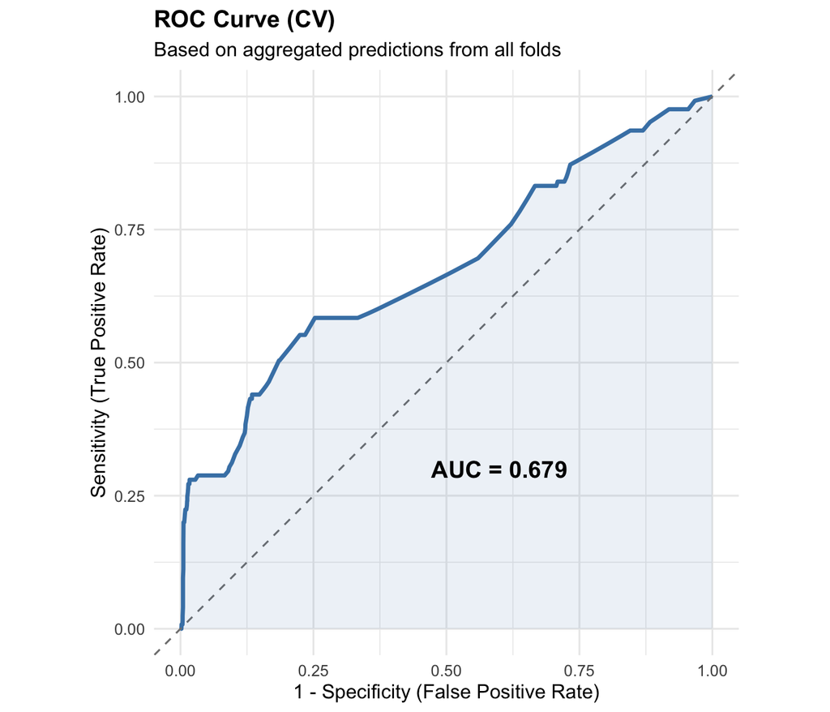

```r
# Curva ROC a partir das predicoes CV
roc_data_progressao <- preds_progressao |>
    roc_curve(truth = delta_progression_cart, .pred_progrediu, event_level = "second")

# AUC para o titulo
auc_val_progressao <- preds_progressao |>
    roc_auc(truth = delta_progression_cart, .pred_progrediu, event_level = "second") |>
    pull(.estimate)

ggplot(roc_data_progressao, aes(x = 1 - specificity, y = sensitivity)) +
    geom_path(linewidth = 1.2, color = "steelblue") +
    geom_abline(linetype = "dashed", color = "gray50") +
    geom_ribbon(
        aes(ymin = 0, ymax = sensitivity),
        alpha = 0.1,
        fill = "steelblue"
    ) +
    annotate(
        "text",
        x = 0.6,
        y = 0.3,
        label = paste0("AUC = ", round(auc_val_progressao, 3)),
        size = 5,
        fontface = "bold"
    ) +
    labs(
        title = "ROC Curve (CV)",
        subtitle = "Based on aggregated predictions from all folds",
        x = "1 - Specificity (False Positive Rate)",
        y = "Sensitivity (True Positive Rate)"
    ) +
    coord_equal() +
    theme_minimal(base_size = 12) +
    theme(plot.title = element_text(face = "bold"))
```